# Data Munging

Daniel S. Hain (dsh@business.aau.dk)

today

# 1 Introduction

In this session, you will learn the basic grammar of data manipulation and visualization, and some best-practice advices. We will here focus mainly on

- Obtaining our data
- Scrubbing / Cleaning our data
- SUmmarizing our data
- Visualizing our data

In this session, you will learn:

- How to do basic variable filtering, selection, and manipulation
- How to create various types of data summarization
- How to also apply these actions on grouped data
- How to join data from different sources
- How to reshape your data

From my experience, this covers ca. 95% of common data manipulation tasks. Sound like fun? Lets get started!

# 2 Before we start: Some digression on data manipulation workflows

## 2.1 Reminder: Base-R

### 2.1.1 Basics

#### 2.1.1.1 Assignments

You can assign a value to an object using `assign()`, `<-`, or `=`.

```r
x <- 3         # Assignment
x              # Evaluate the expression and print result
```

```
## [1] 3
```

```r
y <- 4         # Assignment
y + 5          # Evaluation, y remains 4
```

```
## [1] 9
```

```r
z <- x + 17*y  # Assignment
z              # Evaluation
```

```
## [1] 71
```

```r
rm(z)          # Remove z: deletes the object.
# z             # Error!
```

#### 2.1.1.2 Value comparisons

Comparisons return boolean values: `TRUE` or `FALSE` (often abbreviated and equivalent to `T` and `F`)

```r
2==2  # Equality
```

```
## [1] TRUE
```

```r
2!=2  # Inequality
```

```
## [1] FALSE
```

```r
x <= y # less than or equal: "<", ">", and ">=" also work
```

```
## [1] TRUE
```

#### 2.1.1.3 Special constants

`NA`, `NULL`, `Inf`, `-Inf`, `NaN`

```r
# NA - missing or undefined data
5 + NA      # When used in an expression, the result is generally NA
```

```
## [1] NA
```

```r
is.na(5+NA) # Check if missing
```

```
## [1] TRUE
```

```r
# NULL - an empty object, e.g. a null/empty list
10 + NULL     # use returns an empty object (length zero)
```

```
## numeric(0)
```

```r
is.null(NULL) # check if NULL
```

```
## [1] TRUE
```

```r
# Inf and -Inf represent positive and negative infinity
# They can be returned by  mathematical operations like division of a number by zero:

5/0
```

```
## [1] Inf
```

```r
is.finite(5/0) # Check if a number is finite
```

```
## [1] FALSE
```

```r
# NaN (Not a Number) - the result of an operation that cannot be reasonably defined
0/0
```

```
## [1] NaN
```

```r
is.nan(0/0)
```

```
## [1] TRUE
```

### 2.1.2 Object classes

#### 2.1.2.1 Vectors

```r
v1 <- c(1, 5, 11, 33)       # Numeric vector, length 4
v2 <- c("hello","world")    # Character vector, length 2 (a vector of strings)
v3 <- c(TRUE, TRUE, FALSE)  # Logical vector, same as c(T, T, F)
```

Combining different types of elements in one vector will coerce the elements to the least restrictive type:

```r
v4 <- c(v1,v2,v3,"boo")     # All elements turn into strings
```

Other ways to create vectors:

```r
v <- 1:7         # same as c(1,2,3,4,5,6,7)
v <- rep(0, 77)  # repeat zero 77 times: v is a vector of 77 zeroes
v <- rep(1:3, times=2) # Repeat 1,2,3 twice
v <- rep(1:10, each=2) # Repeat each element twice
v <- seq(10,20,2) # sequence: numbers between 10 and 20, in jumps of 2

length(v)        # check the length of the vector
```

```
## [1] 6
```

```r
v1 <- 1:5         # 1,2,3,4,5
v2 <- rep(1,5)    # 1,1,1,1,1
```

Element-wise operations:

```r
v1 + v2      # Element-wise addition
```

```
## [1] 2 3 4 5 6
```

```r
v1 + 1       # Add 1 to each element
```

```
## [1] 2 3 4 5 6
```

```r
v1 * 2       # Multiply each element by 2
```

```
## [1]  2  4  6  8 10
```

```r
v1 + c(1,7)  # This doesn't work: (1,7) is a vector of different length
```

```
## [1]  2  9  4 11  6
```

Mathematical operations:

```r
sum(v1)      # The sum of all elements
```

```
## [1] 15
```

```r
mean(v1)     # The average of all elements
```

```
## [1] 3
```

```r
sd(v1)       # The standard deviation
```

```
## [1] 1.581139
```

```r
cor(v1,v1*5) # Correlation between v1 and v1*5
```

```
## [1] 1
```

Logical operations:

```r
v1 > 2       # Each element is compared to 2, returns logical vector
```

```
## [1] FALSE FALSE  TRUE  TRUE  TRUE
```

```r
v1==v2       # Are corresponding elements equivalent, returns logical vector.
```

```
## [1]  TRUE FALSE FALSE FALSE FALSE
```

```r
v1!=v2       # Are corresponding elements *not* equivalent? Same as !(v1==v2)
```

```
## [1] FALSE  TRUE  TRUE  TRUE  TRUE
```

```r
(v1>2) | (v2>0)   # | is the boolean OR, returns a vector.
```

```
## [1] TRUE TRUE TRUE TRUE TRUE
```

```r
(v1>2) & (v2>0)   # & is the boolean AND, returns a vector.
```

```
## [1] FALSE FALSE  TRUE  TRUE  TRUE
```

```r
(v1>2) || (v2>0)  # || is the boolean OR, returns a single value
```

```
## [1] TRUE
```

```r
(v1>2) && (v2>0)  # && is the boolean AND, ditto
```

```
## [1] FALSE
```

Vector elements:

```r
v1[3]             # third element of v1
```

```
## [1] 3
```

```r
v1[2:4]           # elements 2, 3, 4 of v1
```

```
## [1] 2 3 4
```

```r
v1[c(1,3)]        # elements 1 and 3 - note that your indexes are a vector
```

```
## [1] 1 3
```

```r
v1[c(T,T,F,F,F)]  # elements 1 and 2 - only the ones that are TRUE
```

```
## [1] 1 2
```

```r
v1[v1>3]          # v1>3 is a logical vector TRUE for elements >3
```

```
## [1] 4 5
```

**NOTE:** If you are used to languages indexing from 0, R will surprise you by indexing from 1.

To add more elements to a vector, simply assign them values.

```r
v1[6:10] <- 6:10
```

We can also directly assign the vector a length:

```r
length(v1) <- 15 # the last 5 elements are added as missing data: NA
```

#### 2.1.2.2 Factors ——–

Factors are used to store categorical data.

```r
eye.col.v <- c("brown", "green", "brown", "blue", "blue", "blue")         #vector
eye.col.f <- factor(c("brown", "green", "brown", "blue", "blue", "blue")) #factor
eye.col.v
```

```
## [1] "brown" "green" "brown" "blue"  "blue"  "blue"
```

```r
eye.col.f
```

```
## [1] brown green brown blue  blue  blue
## Levels: blue brown green
```

`R` will identify the different levels of the factor - e.g. all distinct values. The data is stored internally as integers - each number corresponding to a factor level.

```r
levels(eye.col.f)  # The levels (distinct values) of the factor (categorical variable)
```

```
## [1] "blue"  "brown" "green"
```

```r
as.numeric(eye.col.f)  # The factor as numeric values: 1 is  blue, 2 is brown, 3 is green
```

```
## [1] 2 3 2 1 1 1
```

```r
as.numeric(eye.col.v)  # The character vector, however, can not be coerced to numeric
```

```
## [1] NA NA NA NA NA NA
```

```r
as.character(eye.col.f)
```

```
## [1] "brown" "green" "brown" "blue"  "blue"  "blue"
```

```r
as.character(eye.col.v)
```

```
## [1] "brown" "green" "brown" "blue"  "blue"  "blue"
```

#### 2.1.2.3 Matrces & Arrays

A matrix is a vector with dimensions:

```r
m <- rep(1, 20)   # A vector of 20 elements, all 1
dim(m) <- c(5,4)  # Dimensions set to 5 & 4, so m is now a 5x4 matrix
```

Create a matrix using `matrix()`:

```r
m <- matrix(data=1, nrow=5, ncol=4)  # same matrix as above, 5x4, full of 1s
m <- matrix(1,5,4)                       # same matrix as above
dim(m)                                # What are the dimensions of m?
```

```
## [1] 5 4
```

Create a matrix by combining vectors:

```r
m <- cbind(1:5, 5:1, 5:9)  # Bind 3 vectors as columns, 5x3 matrix
m <- rbind(1:5, 5:1, 5:9)  # Bind 3 vectors as rows, 3x5 matrix
m <- matrix(1:10,10,10)
```

Select matrix elements:

```r
m[2,3]  # Matrix m, row 2, column 3 - a single cell
```

```
## [1] 2
```

```r
m[2,]   # The whole second row of m as a vector
```

```
##  [1] 2 2 2 2 2 2 2 2 2 2
```

```r
m[,2]   # The whole second column of m as a vector
```

```
##  [1]  1  2  3  4  5  6  7  8  9 10
```

```r
m[1:2,4:6] # submatrix: rows 1 and 2, columns 4, 5 and 6
```

```
##      [,1] [,2] [,3]
## [1,]    1    1    1
## [2,]    2    2    2
```

```r
m[-1,]     # all rows *except* the first one
```

```
##       [,1] [,2] [,3] [,4] [,5] [,6] [,7] [,8] [,9] [,10]
##  [1,]    2    2    2    2    2    2    2    2    2     2
##  [2,]    3    3    3    3    3    3    3    3    3     3
##  [3,]    4    4    4    4    4    4    4    4    4     4
##  [4,]    5    5    5    5    5    5    5    5    5     5
##  [5,]    6    6    6    6    6    6    6    6    6     6
##  [6,]    7    7    7    7    7    7    7    7    7     7
##  [7,]    8    8    8    8    8    8    8    8    8     8
##  [8,]    9    9    9    9    9    9    9    9    9     9
##  [9,]   10   10   10   10   10   10   10   10   10    10
```

```r
m[1,]==m[,1]  # Are elements in row 1 equivalent to corresponding elements from column 1?
```

```
##  [1]  TRUE FALSE FALSE FALSE FALSE FALSE FALSE FALSE FALSE FALSE
```

```r
m>3           # A logical matrix: TRUE for m elements >3, FALSE otherwise
```

```
##        [,1]  [,2]  [,3]  [,4]  [,5]  [,6]  [,7]  [,8]  [,9] [,10]
##  [1,] FALSE FALSE FALSE FALSE FALSE FALSE FALSE FALSE FALSE FALSE
##  [2,] FALSE FALSE FALSE FALSE FALSE FALSE FALSE FALSE FALSE FALSE
##  [3,] FALSE FALSE FALSE FALSE FALSE FALSE FALSE FALSE FALSE FALSE
##  [4,]  TRUE  TRUE  TRUE  TRUE  TRUE  TRUE  TRUE  TRUE  TRUE  TRUE
##  [5,]  TRUE  TRUE  TRUE  TRUE  TRUE  TRUE  TRUE  TRUE  TRUE  TRUE
##  [6,]  TRUE  TRUE  TRUE  TRUE  TRUE  TRUE  TRUE  TRUE  TRUE  TRUE
##  [7,]  TRUE  TRUE  TRUE  TRUE  TRUE  TRUE  TRUE  TRUE  TRUE  TRUE
##  [8,]  TRUE  TRUE  TRUE  TRUE  TRUE  TRUE  TRUE  TRUE  TRUE  TRUE
##  [9,]  TRUE  TRUE  TRUE  TRUE  TRUE  TRUE  TRUE  TRUE  TRUE  TRUE
## [10,]  TRUE  TRUE  TRUE  TRUE  TRUE  TRUE  TRUE  TRUE  TRUE  TRUE
```

```r
m[m>3]        # Selects only TRUE elements - that is ones greater than 3
```

```
##  [1]  4  5  6  7  8  9 10  4  5  6  7  8  9 10  4  5  6  7  8  9 10  4  5
## [24]  6  7  8  9 10  4  5  6  7  8  9 10  4  5  6  7  8  9 10  4  5  6  7
## [47]  8  9 10  4  5  6  7  8  9 10  4  5  6  7  8  9 10  4  5  6  7  8  9
## [70] 10
```

```r
t(m)          # Transpose m
```

```
##       [,1] [,2] [,3] [,4] [,5] [,6] [,7] [,8] [,9] [,10]
##  [1,]    1    2    3    4    5    6    7    8    9    10
##  [2,]    1    2    3    4    5    6    7    8    9    10
##  [3,]    1    2    3    4    5    6    7    8    9    10
##  [4,]    1    2    3    4    5    6    7    8    9    10
##  [5,]    1    2    3    4    5    6    7    8    9    10
##  [6,]    1    2    3    4    5    6    7    8    9    10
##  [7,]    1    2    3    4    5    6    7    8    9    10
##  [8,]    1    2    3    4    5    6    7    8    9    10
##  [9,]    1    2    3    4    5    6    7    8    9    10
## [10,]    1    2    3    4    5    6    7    8    9    10
```

```r
m <- t(m)     # Assign m the transposed m
m %*% t(m)    # %*% does matrix multiplication
```

```
##       [,1] [,2] [,3] [,4] [,5] [,6] [,7] [,8] [,9] [,10]
##  [1,]  385  385  385  385  385  385  385  385  385   385
##  [2,]  385  385  385  385  385  385  385  385  385   385
##  [3,]  385  385  385  385  385  385  385  385  385   385
##  [4,]  385  385  385  385  385  385  385  385  385   385
##  [5,]  385  385  385  385  385  385  385  385  385   385
##  [6,]  385  385  385  385  385  385  385  385  385   385
##  [7,]  385  385  385  385  385  385  385  385  385   385
##  [8,]  385  385  385  385  385  385  385  385  385   385
##  [9,]  385  385  385  385  385  385  385  385  385   385
## [10,]  385  385  385  385  385  385  385  385  385   385
```

```r
m * m         # * does element-wise multiplication
```

```
##       [,1] [,2] [,3] [,4] [,5] [,6] [,7] [,8] [,9] [,10]
##  [1,]    1    4    9   16   25   36   49   64   81   100
##  [2,]    1    4    9   16   25   36   49   64   81   100
##  [3,]    1    4    9   16   25   36   49   64   81   100
##  [4,]    1    4    9   16   25   36   49   64   81   100
##  [5,]    1    4    9   16   25   36   49   64   81   100
##  [6,]    1    4    9   16   25   36   49   64   81   100
##  [7,]    1    4    9   16   25   36   49   64   81   100
##  [8,]    1    4    9   16   25   36   49   64   81   100
##  [9,]    1    4    9   16   25   36   49   64   81   100
## [10,]    1    4    9   16   25   36   49   64   81   100
```

#### 2.1.2.4 Arrays: more than 2 dimensions

Created with the `array()` function:

```r
a <- array(data=1:18,dim=c(3,3,2)) # 3d with dimensions 3x3x2
a <- array(1:18,c(3,3,2))          # the same array
```

#### 2.1.2.5 Lists

Lists are collections of objects (e.g. of strings, vectors, matrices, other lists, etc.)

```r
l1 <- list(boo=v1,foo=v2,moo=v3,zoo="Animals!")  # A list with four components
l2 <- list(v1,v2,v3,"Animals!")

l3 <- list()
l4 <- NULL

l1["boo"]      # Access boo: this returns a list.
```

```
## $boo
##  [1]  1  2  3  4  5  6  7  8  9 10 NA NA NA NA NA
```

```r
l1[["boo"]]    # Access boo: this returns the numeric vector
```

```
##  [1]  1  2  3  4  5  6  7  8  9 10 NA NA NA NA NA
```

```r
l1[[1]]        # Returns the first component of the list, equivalent to above.
```

```
##  [1]  1  2  3  4  5  6  7  8  9 10 NA NA NA NA NA
```

```r
l1$boo         # Named elements can be accessed using the $ operator - equivalent to [[]]
```

```
##  [1]  1  2  3  4  5  6  7  8  9 10 NA NA NA NA NA
```

Add more elements to a list:

```r
l3[[1]] <- 11 # add an element to the empty list l3
l4[[3]] <- c(22, 23) # add a vector as element 3 in the empty list l4.
                     # Since we added element 3, elements 1 & 2 will be generated and empty (NULL)
l1[[5]] <- "More elements!" # The list l1 had 4 elements, we're adding a 5th here.
l1[[8]] <- 1:11 # We added an 8th element, but not 6th or 7th. Those will be created empty (NULL)
l1$Something <- "A thing"  # Adds a ninth element - "A thing", named "Something"
```

#### 2.1.2.6 Data Frames

The data frame is a special kind of list used for storing dataset tables. Think of rows as cases, columns as variables. Each column is a vector or factor.

Creating a dataframe:

```r
dfr1 <- data.frame( ID=1:4,
                    FirstName=c("John","Jim","Jane","Jill"),
                    Female=c(F,F,T,T),
                    Age=c(22,33,44,55) )

dfr1$FirstName   # Access the second column of dfr1.
```

```
## [1] John Jim  Jane Jill
## Levels: Jane Jill Jim John
```

Notice that R thinks this is a categorical variable and so it’s treating it like a factor, not a character vector.

Let’s get rid of the factor by telling R to treat FirstName as a vector:

```r
dfr1$FirstName <- as.vector(dfr1$FirstName)
```

Alternatively, you can tell R you don’t like factors from the start using `stringsAsFactors=FALSE`

```r
dfr2 <- data.frame(FirstName=c("John","Jim","Jane","Jill"), stringsAsFactors=FALSE)
dfr2$FirstName   # Success: not a factor.
```

```
## [1] "John" "Jim"  "Jane" "Jill"
```

Access elements of the data frame

```r
dfr1[1,]   # First row, all columns
```

|  | ID | FirstName | Female | Age |
| --- | --- | --- | --- | --- |
| 1 | 1 | John | FALSE | 22 |

```r
dfr1[,1]   # First column, all rows
```

```
## [1] 1 2 3 4
```

```r
dfr1$Age   # Age column, all rows
```

```
## [1] 22 33 44 55
```

```r
dfr1[1:2,3:4] # Rows 1 and 2, columns 3 and 4 - the gender and age of John & Jim
```

|  | Female | Age |
| --- | --- | --- |
| 1 | FALSE | 22 |
| 2 | FALSE | 33 |

```r
dfr1[c(1,3),] # Rows 1 and 3, all columns
```

|  | ID | FirstName | Female | Age |
| --- | --- | --- | --- | --- |
| 1 | 1 | John | FALSE | 22 |
| 3 | 3 | Jane | TRUE | 44 |

Find the names of everyone over the age of 30 in the data

```r
dfr1[dfr1$Age>30,2]
```

```
## [1] "Jim"  "Jane" "Jill"
```

Find the average age of all females in the data:

```r
mean ( dfr1[dfr1$Female==TRUE,4] )
```

```
## [1] 49.5
```

### 2.1.3 Flow Control (loops & friends)

`if (condition) expr1 else expr2`

```r
x <- 5; y <- 10
if (x==0) y <- 0 else y <- y/x
y
```

```
## [1] 2
```

`for (variable in sequence) expr`

```r
ASum <- 0; AProd <- 1
for (i in 1:x)
{
  ASum <- ASum + i
  AProd <- AProd * i
}
ASum  # equivalent to sum(1:x)
```

```
## [1] 15
```

```r
AProd # equivalemt to prod(1:x)
```

```
## [1] 120
```

`while (condintion) expr`

```r
while (x > 0) {print(x); x <- x-1;}
```

```
## [1] 5
## [1] 4
## [1] 3
## [1] 2
## [1] 1
```

`repeat expr, use break to exit the loop`

```r
repeat { print(x); x <- x+1; if (x>10) break}
```

```
## [1] 0
## [1] 1
## [1] 2
## [1] 3
## [1] 4
## [1] 5
## [1] 6
## [1] 7
## [1] 8
## [1] 9
## [1] 10
```

### 2.1.4 R troubleshooting

While I generate many (and often very creative) errors in R, there are three simple things that will most often go wrong for me. Those include:

- Capitalization. R is case sensitive - a graph vertex named “Jack” is not the same as one named “jack”. The function `rowSums` won’t work as “rowsums” or “RowSums”.
- Object class. While many functions are willing to take anything you throw at them, some will still surprisingly require character vector or a factor instead of a numeric vector, or a matrix instead of a data frame. Functions will also occasionally return results in an unexpected format.
- Package namespaces. Occasionally problems will arise when different packages contain functions with the same name. R may warn you about this by saying something like “The following object(s) are masked from ‘package:igraph’” as you load a package. One way to deal with this is to call functions from a package explicitly using ‘::’. For instance, if function ‘blah’ is present in packages A and B, you can call A::blah and B::blah. In other cases the problem is more complicated, and you may have to load packages in certain order, or not use them together at all. For example (and pertinent to this workshop), igraph and statnet packages can cause some problems when loaded at the same time. It is best to detach one before loading the other.

```r
# library(dplyr)          # load a package
# detach(package:dplyr)   # detach a package
```

For more advanced troubleshooting, check out `try()`, `tryCatch()`, and `debug()`.

```r
?tryCatch
```

Generally, just using `?functionyouwonderabout` often solves problems. There you can review the functions arguments, inputs, outputs, syntax etc.

```r
?merge
```

# 3 Introducing [`dplyr`](https://dplyr.tidyverse.org/) workflows

Base R comes with quite some functionality for slicing and dicing data, there also exists a myriad specialized packages for more tricky data manipulation. To read others’ code and example as well as to perform some special operations, you all should be able to use standard R syntax. Lets create a super-simple dataframe and slice it a bit. Lets imagine we have 10 persons with a corresponging numeric id, and some value, such as an IQ score. Soem are members of group A, and some of group B or C. We generate that all somnewhat random:

```r
x <- data.frame(id = 1:10,
                group = sample(LETTERS[1:3], 10, replace = TRUE),
                score = rnorm(10, mean = 0, sd = 1) )
x
```

| id | group | score |
| --- | --- | --- |
| 1 | A | 1.18410577 |
| 2 | C | 0.01930447 |
| 3 | B | -0.07105820 |
| 4 | B | -0.13958716 |
| 5 | C | -1.40903418 |
| 6 | B | 0.95988953 |
| 7 | C | 0.89369640 |
| 8 | C | -1.09291431 |
| 9 | B | -0.52450168 |
| 10 | A | 1.17576368 |

Now, lets imaging we would like to sort, subset or aggregate it, we would do stuff like:

```r
# ordering by score
x[order(x$score),]
```

|  | id | group | score |
| --- | --- | --- | --- |
| 5 | 5 | C | -1.40903418 |
| 8 | 8 | C | -1.09291431 |
| 9 | 9 | B | -0.52450168 |
| 4 | 4 | B | -0.13958716 |
| 3 | 3 | B | -0.07105820 |
| 2 | 2 | C | 0.01930447 |
| 7 | 7 | C | 0.89369640 |
| 6 | 6 | B | 0.95988953 |
| 10 | 10 | A | 1.17576368 |
| 1 | 1 | A | 1.18410577 |

or

```r
# selecting only positive scores
x[x$score >= 0,]
```

|  | id | group | score |
| --- | --- | --- | --- |
| 1 | 1 | A | 1.18410577 |
| 2 | 2 | C | 0.01930447 |
| 6 | 6 | B | 0.95988953 |
| 7 | 7 | C | 0.89369640 |
| 10 | 10 | A | 1.17576368 |

or

```r
# replacing negative scores with zero
x[x$score < 0, "score"] <- 0
```

while that is all possible, the `[row, column]` syntax is not very comfortable. Further, for more tricky operation such as certain aggregations etc., one has to rely on a variety of packages, which often come with an own syntax.

The good news is: The efforts of a small set of key-developers (foremost [Hadley Wickham](http://hadley.nz/)) has let to the development of the [`tidyverse`](https://www.tidyverse.org/), an ecosystem of R packages particularly designed for data science applications. All packages share an underlying design philosophy, common API, grammar, and data structures.

Among the most amazing contributions here is [`dplyr`](https://dplyr.tidyverse.org/), a grammar of data manipulation, providing a consistent set of verbs that help you solve the most common data manipulation challenges. I use `dplyr` for 90% of my data-manipulation tasks for the following reasons:

- All the underlying code is runs optimized in `C++`, making it faster than most base R
- It consistently unifies the grammar of data manipulation to a small set of operations, which can be flexibly combined to master almost every task
- It is designed to work neathly with the `%>%` pipe-operator of magrittr (more on that later)
- its syntax is very similar to the logic of `SQL` and other data-management languages
- It expanded far beoyond its original 5 verbs, and now replaces most base R commands with optimized, clever, and high-performance altgernatives
- It works neathly with many databases, such as `SQL`

I will not touch on all packages there, but the complete `tidyverse` covers almost all issues of data manipulation. They all operate under the same logic, are fast, and usually your best choice for almost any given problem. Particularly `dplyr` is enourmeously powerfull, and has a lot more functions than the basics I cover here. So, for every given probloblem, your first question (to yourself or [stackoverflow](https://stackoverflow.com/)) should be:

1: Is there a way to solve my problem in `dplyr`? 2: If not, is there another `tidyverse` package dedicated to this problem?

## 3.1 General syntax

So, let’s zoom in the `dplyr` functionality and syntax for a moment, before we illustrate it at the following data-manipulation tasks.

dplyr is designed to abstract over how the data is stored. That means as well as working with local data frames, you can also work with remote database tables, using exactly the same R code. Install the `dbplyr` package then read `vignette("databases", package = "dbplyr")`.

First, let’s install (if necessary) and load it. For the sake of illustration, I will load every package of the `tidyverse` one-by-one when we need it. However, normally I just load `library(tidyverse)` all at once, since I need a lot of these packages often anyhow

```r
# # The easiest way to get dplyr is to install the whole tidyverse, including GGplot2 and all the stuff we will need later anyhow:
# install.packages("tidyverse")
# library(tidyverse) # To load the whole compilation of packages
library(dplyr)
library(magrittr) # For some advanced piping operations not included in dplyr
```

### 3.1.1 Piping in `dplyr`

[figure not shown]

in traditional R syntax, data-manipulations are carried out one by one. For example, one would first assign a new variable `x$numbers <- 1:5`, then maybe manipulate it `x$numbers <- x$numbers * 2`, and subset it `x <- x[x$numbers > 4]`. `dplyr` makes use of `margrittr`’s pipes, written like `%>%`. A pipe means take the output of it’s left-hand side and insert it as first input in the function on the right-hand side. Accordingly, all `dplyr` functions follow the syntax that their first input is always the data to be manipulated. Therefore, they can all be “piped”.

The example before we could pipe as follows:

```r
x <- data_frame(numbers = 1:5) %>%
  mutate(numbers = numbers * 2) %>%
  filter(numbers > 4)

x
```

[output not shown]

It basically reads lite: Create a dataframe (to be precise, a `tibble`) with the variable “numbers” and assign the values 1:5 THEN multiply them with 2 THEN subset the dataframe to only rows with a nuimber value higher than 4.

It first looks not so intuitive, but it will become your second nature. Using pipes facilitates fast, reproducible and easily readable coding practices, and all of you are encouraged to go on with that.

One note: `%>%` pipes do not autometically assign their output to the left-hand side object, meaning the original dataset will not per se be overwritten. To do that, there are two ways: 1: Initially, assign the output to the original data with `<-` 2: Initially, use `margrittr`’s `%<>%` command, meaning: Assign and pipe.

```r
x <- x %>%
  filter(numbers > 5)

x %<>%
  filter(numbers > 8)
```

In conclusion: The pipe basically passes on dataframe between functions in the following way:

```r
x %>% fun(y)
# Is equivalent to
fun(x, y)

# While
x %<>% fun(y)
# Is equivalent to
x <- fun(x, y)
```

### 3.1.2 The 5 core verbs of data-manipulation

At ity’s core are 5 central verbs of data/manipulation, which are

1. `filter()` picks cases based on their values.
2. `select()` picks variables based on their names.
3. `arrange()` changes the ordering of the rows.
4. `mutate()` adds new variables that are functions of existing variables
5. `summarise()` reduces multiple values down to a single summary.

These all combine naturally with `group_by()` which allows you to perform any operation “by group”. You can learn more about them in `vignette("dplyr")`. As well as these single-table verbs, dplyr also provides a variety of two-table verbs (joins and mutations), which you can learn about in `vignette("two-table")`.

We will explore now a bit with the starwars dataset, which comes together with `dplyr`

```r
head(starwars) # The "startwars" dataset is an integrated dplyr goddie :)
```

| name | height | mass | hair_color | skin_color | eye_color | birth_year | gender | homeworld | species | films | vehicles | starships |
| --- | --- | --- | --- | --- | --- | --- | --- | --- | --- | --- | --- | --- |
| Luke Skywalker | 172 | 77 | blond | fair | blue | 19.0 | male | Tatooine | Human |  |  |  |
| C-3PO | 167 | 75 | NA | gold | yellow | 112.0 | NA | Tatooine | Droid |  |  |  |
| R2-D2 | 96 | 32 | NA | white, blue | red | 33.0 | NA | Naboo | Droid |  |  |  |
| Darth Vader | 202 | 136 | none | white | yellow | 41.9 | male | Tatooine | Human |  |  |  |
| Leia Organa | 150 | 49 | brown | light | brown | 19.0 | female | Alderaan | Human |  |  |  |
| Owen Lars | 178 | 120 | brown, grey | light | blue | 52.0 | male | Tatooine | Human |  |  |  |

For a first inspection of new data, I like the corresponding function in the little `skimr` package, which gives a nice brief summary on data, types, and values.

```r
# install.packages("skimr")
library(skimr)
skim(starwars)
```

|  | variable | type | stat | level | value | formatted |
| --- | --- | --- | --- | --- | --- | --- |
| 1 | name | character | missing | .all | 0.00000 | 0 |
| 2 | name | character | complete | .all | 87.00000 | 87 |
| 3 | name | character | n | .all | 87.00000 | 87 |
| 4 | name | character | min | .all | 3.00000 | 3 |
| 5 | name | character | max | .all | 21.00000 | 21 |
| 6 | name | character | empty | .all | 0.00000 | 0 |
| 7 | name | character | n_unique | .all | 87.00000 | 87 |
| 8 | height | integer | missing | .all | 6.00000 | 6 |
| 9 | height | integer | complete | .all | 81.00000 | 81 |
| 10 | height | integer | n | .all | 87.00000 | 87 |

[output cut: 93 more lines]

#### 3.1.2.1 1: `filter()`

The verb `filter()` lets you subset a dataframe by rows (observations), meaning the output will filter for only rows which fulfill a certain condition.

[figure not shown]

```r
starwars %>%
  filter(species == "Droid")
```

| name | height | mass | hair_color | skin_color | eye_color | birth_year | gender | homeworld | species | films | vehicles | starships |
| --- | --- | --- | --- | --- | --- | --- | --- | --- | --- | --- | --- | --- |
| C-3PO | 167 | 75 | NA | gold | yellow | 112 | NA | Tatooine | Droid |  |  |  |
| R2-D2 | 96 | 32 | NA | white, blue | red | 33 | NA | Naboo | Droid |  |  |  |
| R5-D4 | 97 | 32 | NA | white, red | red | NA | NA | Tatooine | Droid |  |  |  |
| IG-88 | 200 | 140 | none | metal | red | 15 | none | NA | Droid |  |  |  |
| BB8 | NA | NA | none | none | black | NA | none | NA | Droid |  |  |  |

Conditions can be logically combined with boolean operators (`&, |`)

```r
starwars %>%
  filter(homeworld == "Tatooine" & species == "Droid")
```

| name | height | mass | hair_color | skin_color | eye_color | birth_year | gender | homeworld | species | films | vehicles | starships |
| --- | --- | --- | --- | --- | --- | --- | --- | --- | --- | --- | --- | --- |
| C-3PO | 167 | 75 | NA | gold | yellow | 112 | NA | Tatooine | Droid |  |  |  |
| R5-D4 | 97 | 32 | NA | white, red | red | NA | NA | Tatooine | Droid |  |  |  |

#### 3.1.2.2 2: `select()`

The verb `select()` lets you subset a dataframe by column (variable), meaning the output will only contain certain columns in the stated order

```r
starwars %>%
  select(name, homeworld)
```

| name | homeworld |
| --- | --- |
| Luke Skywalker | Tatooine |
| C-3PO | Tatooine |
| R2-D2 | Naboo |
| Darth Vader | Tatooine |
| Leia Organa | Alderaan |
| Owen Lars | Tatooine |
| Beru Whitesun lars | Tatooine |
| R5-D4 | Tatooine |
| Biggs Darklighter | Tatooine |
| Obi-Wan Kenobi | Stewjon |

[output cut: 77 more lines]

It can also be used to deselect columns with a leading `-`

```r
starwars %>%
  select(-birth_year, -skin_color)
```

| name | height | mass | hair_color | eye_color | gender | homeworld | species | films | vehicles | starships |
| --- | --- | --- | --- | --- | --- | --- | --- | --- | --- | --- |
| Luke Skywalker | 172 | 77.0 | blond | blue | male | Tatooine | Human |  |  |  |
| C-3PO | 167 | 75.0 | NA | yellow | NA | Tatooine | Droid |  |  |  |
| R2-D2 | 96 | 32.0 | NA | red | NA | Naboo | Droid |  |  |  |
| Darth Vader | 202 | 136.0 | none | yellow | male | Tatooine | Human |  |  |  |
| Leia Organa | 150 | 49.0 | brown | brown | female | Alderaan | Human |  |  |  |
| Owen Lars | 178 | 120.0 | brown, grey | blue | male | Tatooine | Human |  |  |  |
| Beru Whitesun lars | 165 | 75.0 | brown | blue | female | Tatooine | Human |  |  |  |
| R5-D4 | 97 | 32.0 | NA | red | NA | Tatooine | Droid |  |  |  |
| Biggs Darklighter | 183 | 84.0 | black | brown | male | Tatooine | Human |  |  |  |
| Obi-Wan Kenobi | 182 | 77.0 | auburn, white | blue-gray | male | Stewjon | Human |  |  |  |

[output cut: 77 more lines]

Lastly, many of `dplyr`’s other conditions can be applied to select or deselect columns. More on that later.

```r
starwars %>%
  select(name, ends_with("color"))
```

| name | hair_color | skin_color | eye_color |
| --- | --- | --- | --- |
| Luke Skywalker | blond | fair | blue |
| C-3PO | NA | gold | yellow |
| R2-D2 | NA | white, blue | red |
| Darth Vader | none | white | yellow |
| Leia Organa | brown | light | brown |
| Owen Lars | brown, grey | light | blue |
| Beru Whitesun lars | brown | light | blue |
| R5-D4 | NA | white, red | red |
| Biggs Darklighter | black | light | brown |
| Obi-Wan Kenobi | auburn, white | fair | blue-gray |

[output cut: 77 more lines]

#### 3.1.2.3 3: `arrange()`

The verb `arrange()` defines the way the rows of your dataframe are ordered

[figure not shown]

Arrange

```r
starwars %>%
  arrange(homeworld, desc(mass))
```

| name | height | mass | hair_color | skin_color | eye_color | birth_year | gender | homeworld | species | films | vehicles | starships |
| --- | --- | --- | --- | --- | --- | --- | --- | --- | --- | --- | --- | --- |
| Raymus Antilles | 188 | 79.0 | brown | light | brown | NA | male | Alderaan | Human |  |  |  |
| Leia Organa | 150 | 49.0 | brown | light | brown | 19.0 | female | Alderaan | Human |  |  |  |
| Bail Prestor Organa | 191 | NA | black | tan | brown | 67.0 | male | Alderaan | Human |  |  |  |
| Ratts Tyerell | 79 | 15.0 | none | grey, blue | unknown | NA | male | Aleen Minor | Aleena |  |  |  |
| Lobot | 175 | 79.0 | none | light | blue | 37.0 | male | Bespin | Human |  |  |  |
| Jek Tono Porkins | 180 | 110.0 | brown | fair | blue | NA | male | Bestine IV | Human |  |  |  |
| Nute Gunray | 191 | 90.0 | none | mottled green | red | NA | male | Cato Neimoidia | Neimodian |  |  |  |
| Ki-Adi-Mundi | 198 | 82.0 | white | pale | yellow | 92.0 | male | Cerea | Cerean |  |  |  |
| Mas Amedda | 196 | NA | none | blue | blue | NA | male | Champala | Chagrian |  |  |  |
| Mon Mothma | 150 | NA | auburn | fair | blue | 48.0 | female | Chandrila | Human |  |  |  |

[output cut: 77 more lines]

#### 3.1.2.4 4: `mutate()`

The verb `mutate()` lets you manipulate existing variables or create new ones.

[figure not shown]

Mutate

```r
starwars %>%
  mutate(bmi = mass / ((height / 100)  ^ 2),
         mass.rel = mass / max(mass, na.rm = TRUE)) %>%
  select(name:mass, mass.rel, bmi) %>%
  arrange(desc(bmi))
```

| name | height | mass | mass.rel | bmi |
| --- | --- | --- | --- | --- |
| Jabba Desilijic Tiure | 175 | 1358.0 | 1.00000000 | 443.42857 |
| Dud Bolt | 94 | 45.0 | 0.03313697 | 50.92802 |
| Yoda | 66 | 17.0 | 0.01251841 | 39.02663 |
| Owen Lars | 178 | 120.0 | 0.08836524 | 37.87401 |
| IG-88 | 200 | 140.0 | 0.10309278 | 35.00000 |
| R2-D2 | 96 | 32.0 | 0.02356406 | 34.72222 |
| Grievous | 216 | 159.0 | 0.11708395 | 34.07922 |
| R5-D4 | 97 | 32.0 | 0.02356406 | 34.00999 |
| Jek Tono Porkins | 180 | 110.0 | 0.08100147 | 33.95062 |
| Darth Vader | 202 | 136.0 | 0.10014728 | 33.33007 |

[output cut: 77 more lines]

#### 3.1.2.5 5: `summarize()`

The verb `summarize()` reduces your dataset to one observation, which is summarized according to a defined function.

[figure not shown]

Summarize

```r
starwars %>%
  summarize(min.height = min(height, na.rm = TRUE),
            mean.height = mean(height, na.rm = TRUE),
            max.height = max(height, na.rm = TRUE),
            sd.height = sd(height, na.rm = TRUE) )
```

| min.height | mean.height | max.height | sd.height |
| --- | --- | --- | --- |
| 66 | 174.358 | 264 | 34.77043 |

#### 3.1.2.6 Doing manipulation by group: `group_by`

Finally, `by_group()` is offers the perfect complement to the 5 basic verbs, since it allows to perform aqll the above mentioned tasks sepperate according to used-defined groupings in one or multiple categories. Lets look at some examples:

[figure not shown]

Group

First of all, it works amazingly well with the `summarize()` verb, producing within group summaries

```r
starwars %>%
  group_by(homeworld) %>%
  summarize(mean.height = mean(height, na.rm = TRUE)) %>%
  ungroup() %>%
  arrange(desc(mean.height))
```

| homeworld | mean.height |
| --- | --- |
| Quermia | 264.0000 |
| Kashyyyk | 231.0000 |
| Kalee | 216.0000 |
| Kamino | 208.3333 |
| Utapau | 206.0000 |
| Cerea | 198.0000 |
| Ojom | 198.0000 |
| Champala | 196.0000 |
| Glee Anselm | 196.0000 |
| Serenno | 193.0000 |

[output cut: 39 more lines]

Note that it is adviced to finish always such operations with `ungroup()`. Otherwise, the still active grouping might at a later point lead to all kind of unforseen results.

### 3.1.3 Your turn

Some little exercises in between: Lets go to this [Kaggle notebook exercise](https://www.kaggle.com/danielhain/sds-2018-m1-2-data-munging-exercise-1) and show what you learned

##### 3.1.3.0.1 Two-table verbs

It’s rare that a data analysis involves only a single table of data. In practice, you’ll normally have many tables that contribute to an analysis, and you need flexible tools to combine them. In `dplyr`, there are three families of verbs that work with two tables at a time:

1. Mutating joins, which add new variables to one table from matching rows in another.
2. Filtering joins, which filter observations from one table based on whether or not they match an observation in the other table.
3. Set operations, which combine the observations in the data sets as if they were set elements.

Among those, mutating joins are the by far most used ones, so we will briefly discuss them here, and cover other types later in the applied part. For questions right away, consult `vignette(two-"two-table")`. Mutating joins allow you to combine variables from multiple tables (merging data). We here assume our data is “tidy” (meaning: rows = observations, columns = variables).

Lets briefly create some example data:

```r
df1 <- data_frame(x = c(1, 2), y = 2:1)
df2 <- data_frame(x = c(1, 3), a = 10, b = "a")
df1
```

| x | y |
| --- | --- |
| 1 | 2 |
| 2 | 1 |

```r
df2
```

| x | a | b |
| --- | --- | --- |
| 1 | 10 | a |
| 3 | 10 | a |

There are 4 types of mutating join to combine variables from dataframe `x` and `y, which differ in their behaviour when a match is not found. We’ll illustrate each with a simple example:

1. `left_join(x, y)` includes all observations in `x`, regardless of whether they match or not. This is the most commonly used join because it ensures that you don’t lose observations from your primary table.

```r
df1 %>% left_join(df2)
```

| x | y | a | b |
| --- | --- | --- | --- |
| 1 | 2 | 10 | a |
| 2 | 1 | NA | NA |

2. `right_join(x, y)` includes all observations in `y`. It’s equivalent to `left_join(y, x)`, but the columns will be ordered differently.

```r
df1 %>% right_join(df2)
```

| x | y | a | b |
| --- | --- | --- | --- |
| 1 | 2 | 10 | a |
| 3 | NA | 10 | a |

```r
df2 %>% left_join(df1)
```

| x | a | b | y |
| --- | --- | --- | --- |
| 1 | 10 | a | 2 |
| 3 | 10 | a | NA |

3. `inner_join(x, y)` only includes observations that match in both `x` and `y`.

```r
df1 %>% inner_join(df2)
```

| x | y | a | b |
| --- | --- | --- | --- |
| 1 | 2 | 10 | a |

4. `full_join()` includes all observations from `x` and `y`.

```r
df1 %>% full_join(df2)
```

| x | y | a | b |
| --- | --- | --- | --- |
| 1 | 2 | 10 | a |
| 2 | 1 | NA | NA |
| 3 | NA | 10 | a |

The left, right and full joins are collectively know as **outer joins**. When a row doesn’t match in an outer join, the new variables are filled in with missing values.

While mutating joins are primarily used to add new variables, they can also generate new observations. If a match is not unique, a join will add all possible combinations (the Cartesian product) of the matching observations:

```r
df1 <- data_frame(x = c(1, 1, 2), y = 1:3)
df2 <- data_frame(x = c(1, 1, 2), z = c("a", "b", "a"))

df1 %>% left_join(df2)
```

| x | y | z |
| --- | --- | --- |
| 1 | 1 | a |
| 1 | 1 | b |
| 1 | 2 | a |
| 1 | 2 | b |
| 2 | 3 | a |

Note: In case of multiple matches in `y`, adittional rows will be added. Therefore, if that is not the behavior you want, use the `distinct()` function afterwards.

By default, joins are performed on the bases of **all** variables appearing in `x` and `y`. You can also specify one or multiple variables that should be matched by using the `by` argument. This can also be used to match on variables with different names in `x` and `y`.

```r
df1 <- data_frame(x = c(3, 2, 1), y = 1:3, z = c(1,3,4))
df2 <- data_frame(x = c(1, 2, 3), y = 2:4, q = c("a", "b", "a"))

df1 %>% left_join(df2, by = "x")
```

| x | y.x | z | y.y | q |
| --- | --- | --- | --- | --- |
| 3 | 1 | 1 | 4 | a |
| 2 | 2 | 3 | 3 | b |
| 1 | 3 | 4 | 2 | a |

```r
df1 %>% left_join(df2, by = c("x", "y"))
```

| x | y | z | q |
| --- | --- | --- | --- |
| 3 | 1 | 1 | NA |
| 2 | 2 | 3 | NA |
| 1 | 3 | 4 | NA |

```r
df1 %>% left_join(df2, by = c("x" = "y"))
```

| x | y | z | x.y | q |
| --- | --- | --- | --- | --- |
| 3 | 1 | 1 | 2 | b |
| 2 | 2 | 3 | 1 | a |
| 1 | 3 | 4 | NA | NA |

#### 3.1.3.1 Final remarks

Even though that doesnt sound too much, when combining them right, these basic verbs will enable you to do ca 80% of common data manipulation tasks.

[figure not shown]

```r
rm(df1, df2, x)
```

#### 3.1.3.2 Your turn

Some little exercises in between: Lets go to this [Kaggle notebook exercise](https://www.kaggle.com/danielhain/sds-2018-m1-2-data-munging-exercise-2) and show what you learned!

# 4 Case Study: Cleaning up historical data on voting of the United Nations General Assembly

So, after we refreshed the basic grammar of data-manipulation, we will put it to a test in the following example. We will step-by-step explore the power of the basic grammar of data-manipulation.

We will use the “UN GEneral Assembly Voting” dataset, and explore the pattern and some underlying mechanisms of country voting choices. Lets get started!

[figure not shown]

Source: Erik Voeten “Data and Analyses of Voting in the UN General Assembly” Routledge Handbook of International Organization, edited by Bob Reinalda (published May 27, 2013). Available at SSRN: http://ssrn.com/abstract=2111149

## 4.1 Step 1: Optaining the deta

Usually, we would now have to download some data online, access it via an API or a local database, or something like that. The full dataset is available at [Harvard’s DataVerse](https://dataverse.harvard.edu/dataset.xhtml?persistentId=hdl:1902.1/12379). For a first warm up, we will skip this part, and use the following data I conveniently prepared for you.

A little hint here in case you want to load a `.csv` and stuff the like: The `data.table` package was a really nice function called `fread()` ( stands for “friendly read”), which by now replases mostly `R`’s standard `read.table`, `read.csv()` ect. since it is just faster, automatically recognizes most data format, and codes the variables smarter. However, back to our data. For my own workflow in R, I prefer to save datasets as `.rds` file, which creates a serialized version of the dataset and then saves it with gzip compression. Thatreduces the disk-space of datasets, while they are still read faster than for example a `.csv`.

```r
votes <- readRDS(url("https://www.dropbox.com/s/dtqu1nl7e7uge87/UN_votes.rds?dl=1"))
```

## 4.2 Step 2: First Inspection

Lets first have a look what’s in the dataset.

```r
votes  %>% head(10)
```

| rcid | session | vote | ccode |
| --- | --- | --- | --- |
| 46 | 2 | 1 | 2 |
| 46 | 2 | 1 | 20 |
| 46 | 2 | 9 | 31 |
| 46 | 2 | 1 | 40 |
| 46 | 2 | 1 | 41 |
| 46 | 2 | 1 | 42 |
| 46 | 2 | 9 | 51 |
| 46 | 2 | 9 | 52 |
| 46 | 2 | 9 | 53 |
| 46 | 2 | 9 | 54 |

We see that the dataset is with 508,929 observations already somewhat large. We find a set of 4 variables. Doesn’t sound so exiting on first glance. Anyhow, lets talk for a moment about the variables we have:

- **`rcid:`** The roll-call ID, serving as an unique identifyer for the resolution vouted on.
- **`session:`** The number of the session of the annual UNGA, starting with 1 for the historically first meeting
- **`vote:`** A numerical code representing the country’s choice of vote:
  - 1 = Yes
  - 2 = Abstain
  - 3 = No
  - 8 = Not present
  - 9 = Not a member
- **`ccode:`** A numerical code to identify the country

So, to sum up: * Every row contains a voting choice for a particular resolution on country level. * Consequently, we will for every resulution have a single row for every country. * All variables are coded numerically

## 4.3 Step 3: Preprocessing

Whatever data you obtian, it usually needs a bit of manual “massage” to be ready for further analysis. Common steps here are

1. Check variable format (dates, strings, numeric etc.)
2. Check variable scaling (range, outliers)
3. Deal with missing values

While there are some more issues you could run into, we in the following go through a couple of common problems and see some easy ways how to solve them.

### 4.3.1 Filtering

One step of data cleaning is removing observations (rows) that you’re not interested in. In this case, you want to remove “Not present” and “Not a member”. Since we are for now not interested in them, lets get rid of them

```r
votes %>% filter(vote <= 3)  %>% head(10)
```

| rcid | session | vote | ccode |
| --- | --- | --- | --- |
| 46 | 2 | 1 | 2 |
| 46 | 2 | 1 | 20 |
| 46 | 2 | 1 | 40 |
| 46 | 2 | 1 | 41 |
| 46 | 2 | 1 | 42 |
| 46 | 2 | 1 | 70 |
| 46 | 2 | 1 | 90 |
| 46 | 2 | 1 | 91 |
| 46 | 2 | 1 | 92 |
| 46 | 2 | 1 | 93 |

### 4.3.2 Adding a year column

The next step of data cleaning is manipulating your variables (columns) to make them more informative. In this case, you have a session column that is hard to interpret intuitively. But since the UN started voting in 1946, and holds one session per year, you can get the year of a UN resolution by adding 1945 to the session number.

```r
votes %>%
  mutate(year = session + 1945)  %>% head(10)
```

| rcid | session | vote | ccode | year |
| --- | --- | --- | --- | --- |
| 46 | 2 | 1 | 2 | 1947 |
| 46 | 2 | 1 | 20 | 1947 |
| 46 | 2 | 9 | 31 | 1947 |
| 46 | 2 | 1 | 40 | 1947 |
| 46 | 2 | 1 | 41 | 1947 |
| 46 | 2 | 1 | 42 | 1947 |
| 46 | 2 | 9 | 51 | 1947 |
| 46 | 2 | 9 | 52 | 1947 |
| 46 | 2 | 9 | 53 | 1947 |
| 46 | 2 | 9 | 54 | 1947 |

### 4.3.3 Adding a country column

The country codes in the ccode column are what’s called [Correlates of War codes](http://cow.dss.ucdavis.edu/data-sets/cow-country-codes), a numerical coding convention for country names. This isn’t ideal for an analysis, since you’d like to work with recognizable country names.

For this and similar cases, the R package [`countrycode`](https://github.com/vincentarelbundock/countrycode) is really practical, since it allows for fast and easy ways to switch between many standard country-coding conventions.

```r
# # In case the package is not installed yet, do that first:
# install.packages("countrycode")
library(countrycode)

votes  %>%
  mutate(country = countrycode(ccode, "cown", "country.name"))  %>% head(10)
```

| rcid | session | vote | ccode | country |
| --- | --- | --- | --- | --- |
| 46 | 2 | 1 | 2 | United States |
| 46 | 2 | 1 | 20 | Canada |
| 46 | 2 | 9 | 31 | Bahamas |
| 46 | 2 | 1 | 40 | Cuba |
| 46 | 2 | 1 | 41 | Haiti |
| 46 | 2 | 1 | 42 | Dominican Republic |
| 46 | 2 | 9 | 51 | Jamaica |
| 46 | 2 | 9 | 52 | Trinidad & Tobago |
| 46 | 2 | 9 | 53 | Barbados |
| 46 | 2 | 9 | 54 | Dominica |

Here,we tell `countrycode` to transfer the Correlates of War Code (“cown”) to the easily readable country name (“country.name”). Other transformations such as to ISO2 and ISO3 alphanumerical codes are also possible. Neath, isn’t it?

Note that we up to now never changed the original `votes` data. All pipes upto now just created an output for illustration. To really change the data, we have to use the assign-and-pipe `%<>%`, or the manual assignment `<-`. So, lets finish this cleaning up and pipe the whole preprocessing all together. Since not all counrty codes matched a country name, we will also filter the unmatchedc out

```r
votes %<>%
  filter(vote <= 3) %>%
  mutate(year = session + 1945,
         country = countrycode(ccode, "cown", "country.name")) %>%
  filter(!is.na(country))
votes %>% head(10)
```

| rcid | session | vote | ccode | year | country |
| --- | --- | --- | --- | --- | --- |
| 46 | 2 | 1 | 2 | 1947 | United States |
| 46 | 2 | 1 | 20 | 1947 | Canada |
| 46 | 2 | 1 | 40 | 1947 | Cuba |
| 46 | 2 | 1 | 41 | 1947 | Haiti |
| 46 | 2 | 1 | 42 | 1947 | Dominican Republic |
| 46 | 2 | 1 | 70 | 1947 | Mexico |
| 46 | 2 | 1 | 90 | 1947 | Guatemala |
| 46 | 2 | 1 | 91 | 1947 | Honduras |
| 46 | 2 | 1 | 92 | 1947 | El Salvador |
| 46 | 2 | 1 | 93 | 1947 | Nicaragua |

## 4.4 Generating first insights

###Summarizing the full dataset In this analysis, we’re going to focus on “% of votes that are yes” as a metric for the “agreeableness” of countries. we’ll start by finding this summary for the entire dataset: the fraction of all votes in their history that were “yes”. Note that within your call to `summarize()`, you can use `n()` to find the total number of votes and `mean(vote == 1)` (since the output of the logical operation is FALSE or TRUE, which is equivalent to 0 or 1) to find the fraction of “yes” votes.

```r
votes %>%
  summarize(total = n(),
            percent_yes = mean(vote == 1) %>% round(2))
```

| total | percent_yes |
| --- | --- |
| 350844 | 0.8 |

Ok, we see that in general, countries tend to be “aggreable”. While nice to know, this is not terribly informative. As always, single numbers tell us little, trends, context, and comparison does usually provide more insights. So lets start with putting this number in perspective.

### 4.4.1 Summarizing by year

The `summarize()` function is especially useful when used within groups. Here, it gives not a overal summary, but one for every group instance. For example, we might like to know how much the average “agreeableness” of countries changed from year to year. To examine this, you can use `group_by()` to perform your summary not for the entire dataset, but within each year.

```r
year <- votes %>%
  arrange(year) %>%
  group_by(year) %>%
  summarize(total = n(),
            percent_yes = mean(vote == 1) %>% round(2))
year  %>% head(10)
```

| year | total | percent_yes |
| --- | --- | --- |
| 1947 | 2039 | 0.57 |
| 1949 | 3469 | 0.44 |
| 1951 | 1434 | 0.59 |
| 1953 | 1537 | 0.63 |
| 1955 | 2169 | 0.69 |
| 1957 | 2708 | 0.61 |
| 1959 | 4326 | 0.59 |
| 1961 | 7482 | 0.57 |
| 1963 | 3308 | 0.73 |
| 1965 | 4382 | 0.71 |

On first galance, it looks like the overall “agreeableness” seems to increase over time.

### 4.4.2 Summarizing by country

In the last exercise, you performed a summary of the votes within each year. You could instead summarize() within each country, which would let you compare voting patterns between countries. For further analysis, we wil create a new dataframe on country level.

```r
country <- votes %>%
  group_by(country) %>%
  summarize(total = n(),
            percent_yes = mean(vote == 1) %>% round(2))
country  %>% head(10)
```

| country | total | percent_yes |
| --- | --- | --- |
| Afghanistan | 2373 | 0.86 |
| Albania | 1695 | 0.72 |
| Algeria | 2213 | 0.90 |
| Andorra | 719 | 0.64 |
| Angola | 1431 | 0.92 |
| Antigua & Barbuda | 1302 | 0.91 |
| Argentina | 2553 | 0.77 |
| Armenia | 758 | 0.75 |
| Australia | 2575 | 0.56 |
| Austria | 2389 | 0.62 |

Let’s inspect this country level voting pattern by looking at the most and least agreable countries by arranging the dataframe.

```r
country %>%
  arrange(desc(percent_yes))  %>% head(10)
```

| country | total | percent_yes |
| --- | --- | --- |
| São Tomé & Príncipe | 1091 | 0.98 |
| Seychelles | 881 | 0.98 |
| Djibouti | 1598 | 0.96 |
| Guinea-Bissau | 1538 | 0.96 |
| Timor-Leste | 326 | 0.96 |
| Comoros | 1133 | 0.95 |
| Mauritius | 1831 | 0.95 |
| Mozambique | 1701 | 0.95 |
| United Arab Emirates | 1934 | 0.95 |
| Yemen | 784 | 0.95 |

```r
country %>%
  arrange(percent_yes)  %>% head(10)
```

| country | total | percent_yes |
| --- | --- | --- |
| Zanzibar | 2 | 0.00 |
| United States | 2568 | 0.27 |
| Israel | 2380 | 0.34 |
| Palau | 369 | 0.34 |
| United Kingdom | 2558 | 0.42 |
| France | 2527 | 0.43 |
| Micronesia (Federated States of) | 724 | 0.44 |
| Belgium | 2568 | 0.49 |
| Marshall Islands | 757 | 0.49 |
| Canada | 2576 | 0.51 |

So, in conclusion: We might want to get rid of countries with very litte total votes.

```r
country %<>%
  filter(total >= 100)
```

## 4.5 First (petite) graphical exploration

### 4.5.1 Digression: The Grammar of graphics, and [`ggplot2`](https://ggplot2.tidyverse.org/)

ggplot2 can be thought of as a mini-language (domain-specific language) within the R language. It is an R implementation of [Wilkinson’s Grammar of Graphics book](https://www.springer.com/gp/book/9780387245447). [A Layered Grammar of Graphics](http://vita.had.co.nz/papers/layered-grammar.pdf) describes Hadley’s implementation of these thoughts in the ggplot2’s design. Conceptually, the main idea behind the Grammar of Graphics is that a statistical graphic is a mapping from variables to aesthetic attributes (x axis value, y axis value, color, shape, size) of geometric objects (points, line, bars). While the Grammar of Graphic contains more elements, we will focus in this brief intro in the two main ones, aestetics and geometries. * **Aestetics:** Devine the “surface” of your plot, in terms of what has to be mapped (size, coplor) on the x and y (and potentially adittional) axes. Aesteticts are defined within the `aes()` function. * **Geometries:** Visual elements you can see in the plot itself, such as bars, lines, and points. They are defined within various `geom_XYZ()` functions. Basically, you define a surface grid and then plot something on top. We will talk about all of that in depth in later sessions, for now that’s all you need to know to understand the following simple examples.

### 4.5.2 Plotting by year

So, lets graphically explore the development of agreeability over time. The code below is very simple. We pass our data `year` to the `ggplot()` function, which here only contains the basic aestetics `aes()`. In this case, we would like to map the `year` on the `x`, and the value of the `percent_yes` variable on the `y` axis. That defines the plot’s surface. Then, we use the `+` to add a geometric element (similar to the `%>%` pipe), in this case a line-plot.

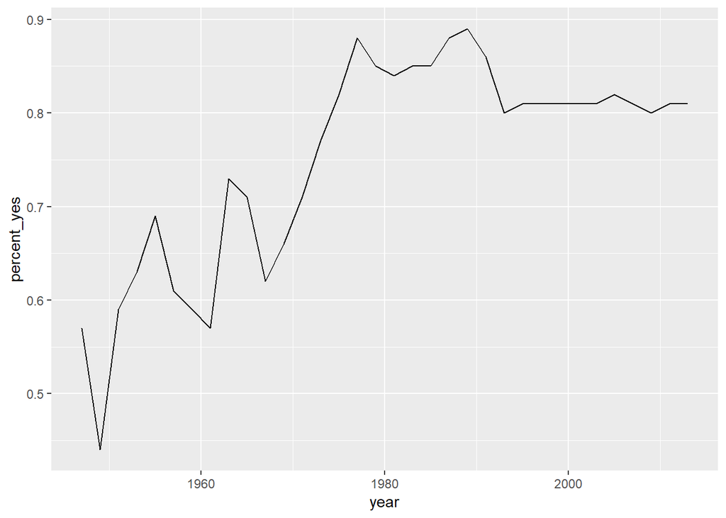

```r
library(ggplot2)

year %>%
  ggplot(aes(x = year, y = percent_yes) ) +
  geom_line()
```

Looks like the trend of increasing agreeability sort of peaked in the 80s.

### 4.5.3 Summarizing by year and country

Ok, that was nice so far, even though not terribly interesting, since it’s hard to interpret aggregated numbers of almost all the world’s countries combined. More tangible insights we might get when zooming in a single country, or comparing trends over a set of countries. Therefore we need a bit of a different data structure. We now need one observation not for year or country, but for every country and year. Fortunatelly, that’s easily done via multiple groupings.

```r
year_country <- votes %>%
  group_by(year, country) %>%
  summarize(total = n(),
            percent_yes = mean(vote == 1))
year_country  %>% head(10)
```

| year | country | total | percent_yes |
| --- | --- | --- | --- |
| 1947 | Afghanistan | 34 | 0.3823529 |
| 1947 | Argentina | 38 | 0.5789474 |
| 1947 | Australia | 38 | 0.5526316 |
| 1947 | Belarus | 38 | 0.5000000 |
| 1947 | Belgium | 38 | 0.6052632 |
| 1947 | Bolivia | 37 | 0.5945946 |
| 1947 | Brazil | 38 | 0.6578947 |
| 1947 | Canada | 38 | 0.6052632 |
| 1947 | Chile | 38 | 0.6578947 |
| 1947 | Colombia | 35 | 0.5428571 |

Ok, with this datastructure, we can do some interesting analysis. For example, we can only look at the development of Danish votes by filtering.

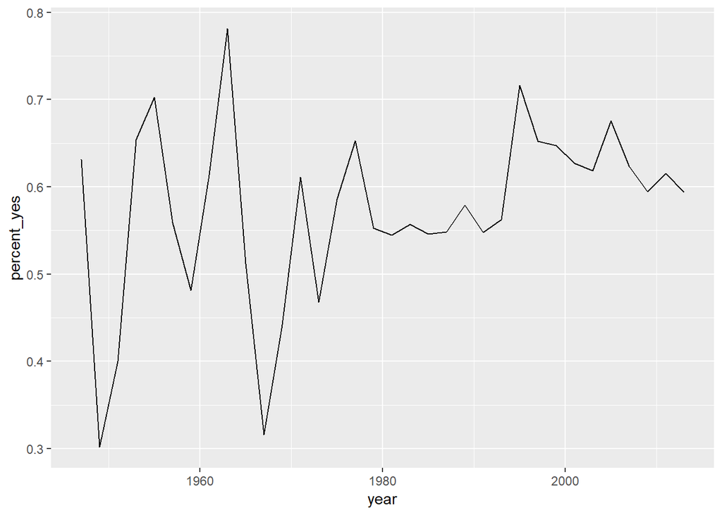

```r
year_country %>%
  filter(country == "Denmark") %>%
  ggplot(aes(x = year, y = percent_yes) ) +
  geom_line()
```

#### 4.5.3.1 Digression: The `%in%` operator

In case we want to compare a set of countries now, it would be convenient if we could select many of them in an easy way. Here, the `%in%` operator is handy. It basically just takes two vectors `x` and `y`, and for every element in `x` returns a Logical indication of this element is also contained in `y`. Example:

```r
c("the", "cake", "is", "a", "lie") %in% c("I", "would", "love", "to", "eat", "a", "cake")
```

```
## [1] FALSE  TRUE FALSE  TRUE FALSE
```

We can following the same idea create a vector of country anmes we want to compare, and then filter our dataset for these countries.

```r
countries <- c("United States", "China", "France", "Denmark")

year_country %>%
  filter(country %in% countries)  %>% head(10)
```

| year | country | total | percent_yes |
| --- | --- | --- | --- |
| 1947 | Denmark | 38 | 0.6315789 |
| 1947 | France | 38 | 0.7368421 |
| 1947 | United States | 38 | 0.7105263 |
| 1949 | Denmark | 63 | 0.3015873 |
| 1949 | France | 64 | 0.3125000 |
| 1949 | United States | 64 | 0.2812500 |
| 1951 | Denmark | 25 | 0.4000000 |
| 1951 | France | 25 | 0.3600000 |
| 1951 | United States | 25 | 0.4000000 |
| 1953 | Denmark | 26 | 0.6538462 |

So,l lets plot these countries. To have them all displayed in one plot, we could either create a `geom_line()` for every subset (would be silly), or define in ggplot’s `aes()` that the categorical variable `country` should be mapped with different colors. Therefore, for every country, a sepperate line in a different color will be created.

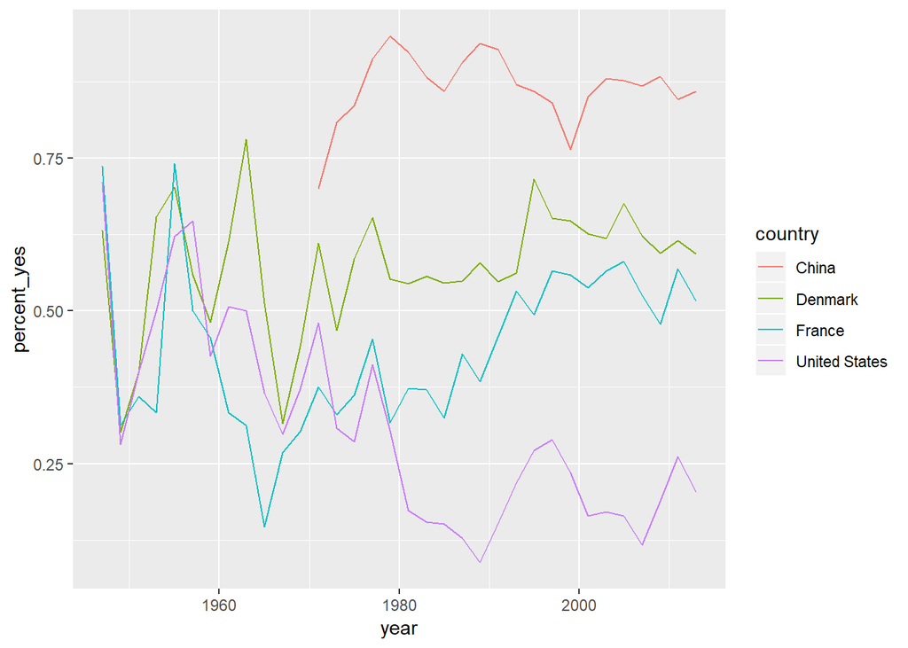

```r
year_country %>%
  filter(country %in% countries) %>%
ggplot(aes(year, percent_yes, color = country)) +
  geom_line()
```

We could obviously go on with all kind of similar graphical analysis, but I do not want to spoiler too much of what is about to come in later sessions. So, lets leave it with that.

## 4.6 Joining our data with contextual information

Up to now, we just looked at general voting pattern, and then a bit more nuanced at pattern over time and across countries. What the specific votes whewre about, we up to now did not really care. However, every vote corresponds to an important geo- and sociopolitic issue. So, it’s time to bring in a bit of context. Therefore, we will now also draw from an adittional dataset with more detailed information on the content of the corresponding vote, which we up to now treated as pure numbers. Lets take a look:

```r
descriptions <- readRDS(url("https://www.dropbox.com/s/k5eym73lwndjbim/UN_votes_descriptions.rds?dl=1"))
descriptions %>% head(10)
```

| rcid | session | date | unres | me | nu | di | hr | co | ec |
| --- | --- | --- | --- | --- | --- | --- | --- | --- | --- |
| 46 | 2 | 1947-09-04 | R/2/299 | 0 | 0 | 0 | 0 | 0 | 0 |
| 47 | 2 | 1947-10-05 | R/2/355 | 0 | 0 | 0 | 1 | 0 | 0 |
| 48 | 2 | 1947-10-06 | R/2/461 | 0 | 0 | 0 | 0 | 0 | 0 |
| 49 | 2 | 1947-10-06 | R/2/463 | 0 | 0 | 0 | 0 | 0 | 0 |
| 50 | 2 | 1947-10-06 | R/2/465 | 0 | 0 | 0 | 0 | 0 | 0 |
| 51 | 2 | 1947-10-02 | R/2/561 | 0 | 0 | 0 | 0 | 1 | 0 |
| 52 | 2 | 1947-11-06 | R/2/650 | 0 | 0 | 0 | 0 | 1 | 0 |
| 53 | 2 | 1947-11-06 | R/2/651 | 0 | 0 | 0 | 0 | 1 | 0 |
| 54 | 2 | 1947-11-06 | R/2/651 | 0 | 0 | 0 | 0 | 1 | 0 |
| 55 | 2 | 1947-11-06 | R/2/667 | 0 | 0 | 0 | 0 | 1 | 0 |

We find the following variables:

- `rcid`: The corresponding ID, which we already know from the previous dataset
- `session`: Likewise, the corresponging session number
- `date`: The day of the vote
- `unres`: The code of the corresponding UN resolution (Check it out in private, is very interesting)

Furthermore, there are 6 “dummy” (meaning 0 or 1 corresponding to FALSE or TRUE) regarding the broad topic of the resolution

- `me`: Palestinian conflict
- `nu`: Nuclear weapons and nuclear material
- `di`: Arms control and disarmament
- `hr`: Human rights
- `co`: Colonialism
- `ec`: Economic development

Little sidenote: We see that the `date` column here is formatted differntly, in the “YYYY-MM-DD” formaat. To transform it to a “YYYY” (year only) format, we could manipulate the string via **regular expressions** the `tidyverse` package [`stringr`](https://stringr.tidyverse.org) (which we will explore a bit later), or in base-R. However, working with differtent time format is always messy, and the `tidyverse` has a dedicated package for it, [`lubridate`](https://lubridate.tidyverse.org/). So we will use this opportunity for a simple date-transformation exercise:

```r
library(lubridate)
descriptions %<>%
  mutate(year = year(date))
descriptions %>% head(10)
```

| rcid | session | date | unres | me | nu | di | hr | co | ec | year |
| --- | --- | --- | --- | --- | --- | --- | --- | --- | --- | --- |
| 46 | 2 | 1947-09-04 | R/2/299 | 0 | 0 | 0 | 0 | 0 | 0 | 1947 |
| 47 | 2 | 1947-10-05 | R/2/355 | 0 | 0 | 0 | 1 | 0 | 0 | 1947 |
| 48 | 2 | 1947-10-06 | R/2/461 | 0 | 0 | 0 | 0 | 0 | 0 | 1947 |
| 49 | 2 | 1947-10-06 | R/2/463 | 0 | 0 | 0 | 0 | 0 | 0 | 1947 |
| 50 | 2 | 1947-10-06 | R/2/465 | 0 | 0 | 0 | 0 | 0 | 0 | 1947 |
| 51 | 2 | 1947-10-02 | R/2/561 | 0 | 0 | 0 | 0 | 1 | 0 | 1947 |
| 52 | 2 | 1947-11-06 | R/2/650 | 0 | 0 | 0 | 0 | 1 | 0 | 1947 |
| 53 | 2 | 1947-11-06 | R/2/651 | 0 | 0 | 0 | 0 | 1 | 0 | 1947 |
| 54 | 2 | 1947-11-06 | R/2/651 | 0 | 0 | 0 | 0 | 1 | 0 | 1947 |
| 55 | 2 | 1947-11-06 | R/2/667 | 0 | 0 | 0 | 0 | 1 | 0 | 1947 |

Neath, isnt it? In similar way, you can easily switch between date formats.

We only have one row per resolution, not as in `votes` one per country vote. Since both dataframes share the `rcid`and `year` variable, we can join on these to augment our votes data with contextual information.

```r
votes_joined <- votes %>% select(-ccode) %>%
  inner_join(descriptions %>% select(-date, -session, -unres), by = c("rcid", "year"))
votes_joined %>% head(10)
```

| rcid | session | vote | year | country | me | nu | di | hr | co | ec |
| --- | --- | --- | --- | --- | --- | --- | --- | --- | --- | --- |
| 46 | 2 | 1 | 1947 | United States | 0 | 0 | 0 | 0 | 0 | 0 |
| 46 | 2 | 1 | 1947 | Canada | 0 | 0 | 0 | 0 | 0 | 0 |
| 46 | 2 | 1 | 1947 | Cuba | 0 | 0 | 0 | 0 | 0 | 0 |
| 46 | 2 | 1 | 1947 | Haiti | 0 | 0 | 0 | 0 | 0 | 0 |
| 46 | 2 | 1 | 1947 | Dominican Republic | 0 | 0 | 0 | 0 | 0 | 0 |
| 46 | 2 | 1 | 1947 | Mexico | 0 | 0 | 0 | 0 | 0 | 0 |
| 46 | 2 | 1 | 1947 | Guatemala | 0 | 0 | 0 | 0 | 0 | 0 |
| 46 | 2 | 1 | 1947 | Honduras | 0 | 0 | 0 | 0 | 0 | 0 |
| 46 | 2 | 1 | 1947 | El Salvador | 0 | 0 | 0 | 0 | 0 | 0 |
| 46 | 2 | 1 | 1947 | Nicaragua | 0 | 0 | 0 | 0 | 0 | 0 |

Here, we perform an `inner_join()`, meaning that it will contain only rows that appear in both dataframes. We do so since we from now on want to look only at votes with contextual information (which are missing in some cases). Note that we deselect unused variables in `description` directly in the join.

Lets look what is voted in ceretain issues. Why not see how the USA over time voted on colonialism related issues.

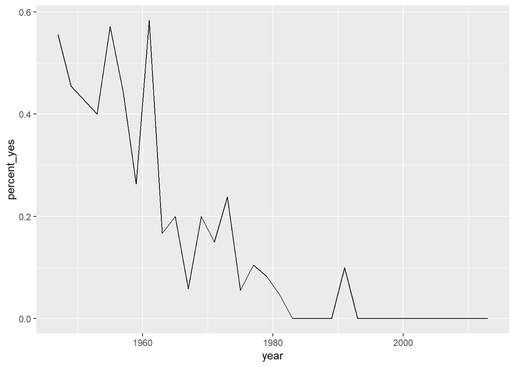

```r
votes_joined %>%
  filter(country == "United States", co == 1) %>%
  group_by(year) %>%
  summarize(percent_yes = mean(vote == 1)) %>%
  ggplot(aes(year, percent_yes)) +
  geom_line()
```

We could also do the same exercise over all topics together in one plot.

## 4.7 Working with tidy data (pivoting, reshaping, or changing between long and wide data formats)

By now, we worked with the traditional data structure, where every column corresponds to one variable. We also call that a **wide*"** data format. This is in most cases the most efficient and prefered way to keep your data. However, there are some cases, where another dataformat would be more convenient.

For example, for range of graphical as well as numerical summaries, it would be nice to have every observation and every variable to be mapped in a single row. This format is also calles **long** (or in R slang, **tidy**) data. Adittionally, some real life datasets (including a lot of WorldBank, Eurostats, OECD, ect.) data is usually available in a long format. Therefore, weare in need of easily switching between long and wide formats, to **reshape** your data (in Excel slang, people call that **pivoting**).

Luckily, R’s `tidyr` package offers you exactly these functionalities in 4 easy functions.

[figure not shown]

tidyr

In detail, they are: * `gather()`: collapse columns into rows (wide to long) * `spread()`: spread two columns into multiple columns (long to wide) * `unite()`: Unite multiple columns into one * `separate()`: separate one column into multiple

### 4.7.1 Tidying our data

For our task, we will now reshape our dataframe from wide to long (tidy), therefore use the `gather()` function. In order to represent the joined vote-topic data in a tidy form so we can analyze and graph by topic, we need to transform the data so that each row has one combination of country-vote-topic. This will change the data from having six columns (`me`, `nu`, `di`, `hr`, `co`, `ec`) to having two columns (`topic` and `has_topic`).

[figure not shown]

Gathering

```r
library(tidyr)
votes_tidy <- votes_joined %>%
  gather(key = topic, value = has_topic, me:ec) %>%
  filter(has_topic == 1)
votes_tidy %>% head(10)
```

| rcid | session | vote | year | country | topic | has_topic |
| --- | --- | --- | --- | --- | --- | --- |
| 77 | 2 | 1 | 1947 | United States | me | 1 |
| 77 | 2 | 1 | 1947 | Canada | me | 1 |
| 77 | 2 | 3 | 1947 | Cuba | me | 1 |
| 77 | 2 | 1 | 1947 | Haiti | me | 1 |
| 77 | 2 | 1 | 1947 | Dominican Republic | me | 1 |
| 77 | 2 | 2 | 1947 | Mexico | me | 1 |
| 77 | 2 | 1 | 1947 | Guatemala | me | 1 |
| 77 | 2 | 2 | 1947 | Honduras | me | 1 |
| 77 | 2 | 2 | 1947 | El Salvador | me | 1 |
| 77 | 2 | 1 | 1947 | Nicaragua | me | 1 |

### 4.7.2 Recoding the topics

There’s one more step of data cleaning to make this more interpretable. To interpret the data more easily, recode the data to replace these codes with their full name. You can do that with `dplyr`’s `recode()` function, which replaces values with ones you specify.

```r
votes_tidy %<>%
  mutate(topic = recode(topic,
                        me = "Palestinian conflict",
                        nu = "Nuclear weapons and nuclear material",
                        di = "Arms control and disarmament",
                        hr = "Human rights",
                        co = "Colonialism",
                        ec = "Economic development"))
```

### 4.7.3 Summarize by country, year, and topic

In previous exercises, you summarized the votes dataset by country, by year, and by country-year combination. Now that you have `topic` as an additional variable, you can summarize the votes for each combination of country, year, and topic (e.g. for the United States in 2013 on the topic of nuclear weapons.). This shows one of the advantages of working with tidy data: The ease to summarize lexible on categort+variable level.

```r
votes_tidy %>%
  group_by(country, year, topic) %>%
  summarize(total = n(), percent_yes = mean(vote == 1)) %>%
  ungroup() %>% head(10)
```

| country | year | topic | total | percent_yes |
| --- | --- | --- | --- | --- |
| Afghanistan | 1947 | Colonialism | 8 | 0.5000000 |
| Afghanistan | 1947 | Economic development | 1 | 0.0000000 |
| Afghanistan | 1947 | Human rights | 1 | 0.0000000 |
| Afghanistan | 1947 | Palestinian conflict | 6 | 0.0000000 |
| Afghanistan | 1949 | Arms control and disarmament | 3 | 0.0000000 |
| Afghanistan | 1949 | Colonialism | 22 | 0.8636364 |
| Afghanistan | 1949 | Economic development | 1 | 1.0000000 |
| Afghanistan | 1949 | Human rights | 3 | 0.0000000 |
| Afghanistan | 1949 | Nuclear weapons and nuclear material | 3 | 0.0000000 |
| Afghanistan | 1949 | Palestinian conflict | 11 | 0.8181818 |

### 4.7.4 Visualizing trends in topics for one country

Now we have a unique mapping of country, year, and topic, therefore can sily create summaries and summary graphs on all kind of level. For example, lets compare how the USA and Denmark over time voted on different topics. To create the plots for all topic at once, we will introduce a new `ggplot2` geometry, a `facet_wrap` over `topic`. This just creates a sepperate plot for every category within `topic`. Just take it here for the sake of illustration, the details will be covered in later sessions.

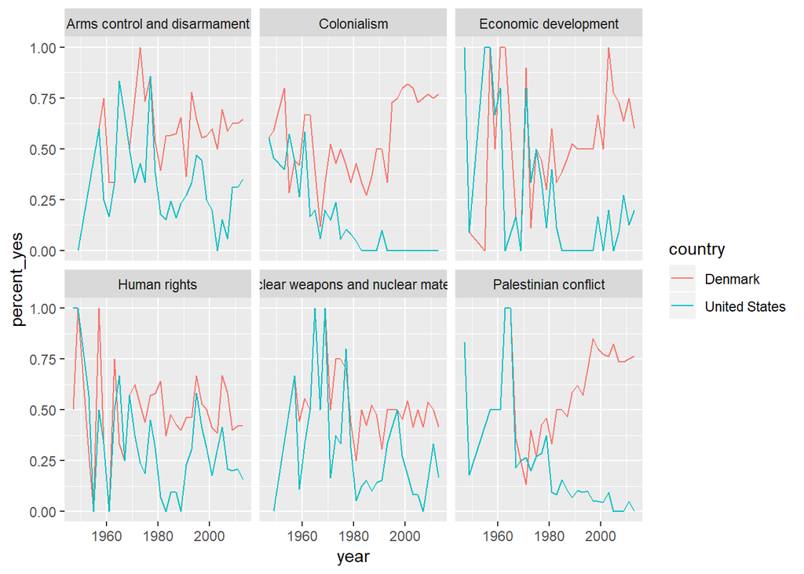

```r
votes_tidy %>%
  group_by(country, year, topic) %>%
  summarize(total = n(), percent_yes = mean(vote == 1)) %>%
  ungroup() %>%
  filter(country %in% c("United States", "Denmark")) %>%
  ggplot(aes(x = year, y = percent_yes, color = country)) +
  geom_line() +
  facet_wrap(~ topic)
```

Up to now, we always created line plots (`geom_line()`), but we could also do a scatterplot (`geom_point()`). To make time-trends more visible, we could add a smoothed trend-line (`geom_smooth(se = FALSE)`, don’t bother with the details for now)

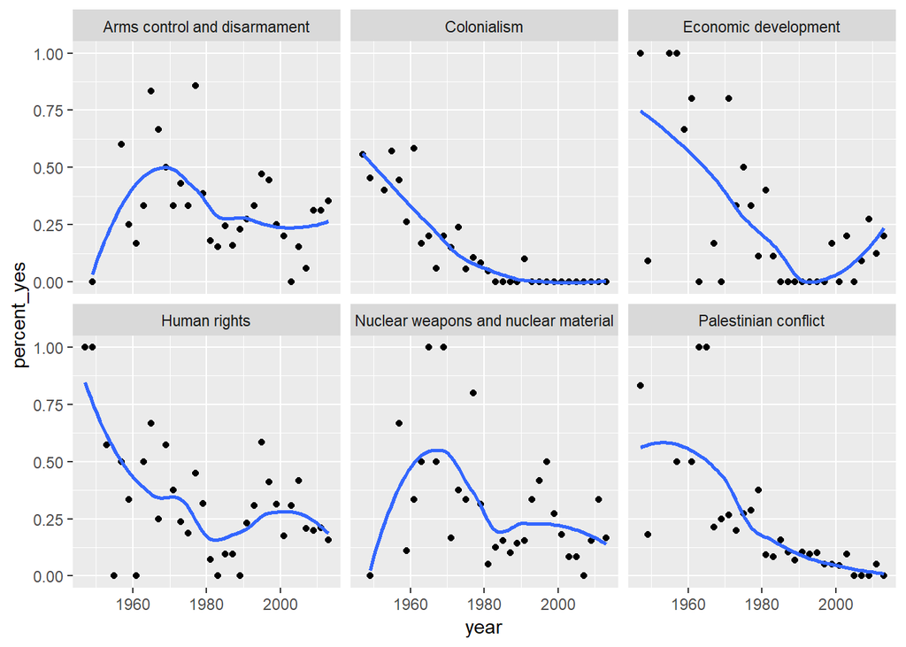

```r
votes_tidy %>%
  group_by(country, year, topic) %>%
  summarize(total = n(), percent_yes = mean(vote == 1)) %>%
  ungroup() %>%
  filter(country == "United States") %>%
  ggplot(aes(x = year, y = percent_yes)) +
  geom_point() +
  geom_smooth(se = FALSE) +
  facet_wrap(~ topic)
```

Ok, byt that’s enough about visualization for now, I do not want to spoiler too much. Only thing I wanted to illustrate here is how easily multiple geometric layers can be added in ine plot.

```r
votes_tidy %>%
  group_by(country, topic) %>%
  summarize(total = n(), percent_yes = mean(vote == 1)) %>%
  ungroup() %>%
  arrange(country, desc(total)) %>%
  group_by(country) %>%
  slice(1) %>%
  ungroup() %>%
  filter(total > 50) %>%
  arrange(desc(percent_yes)) %>% head(10)
```

| country | topic | total | percent_yes |
| --- | --- | --- | --- |
| Azerbaijan | Palestinian conflict | 212 | 1.0000000 |
| Namibia | Palestinian conflict | 225 | 1.0000000 |
| Seychelles | Palestinian conflict | 237 | 1.0000000 |
| Mozambique | Palestinian conflict | 427 | 0.9976581 |
| Djibouti | Palestinian conflict | 426 | 0.9976526 |
| Zimbabwe | Palestinian conflict | 379 | 0.9947230 |
| Bangladesh | Palestinian conflict | 451 | 0.9933481 |
| Comoros | Palestinian conflict | 283 | 0.9929329 |
| São Tomé & Príncipe | Palestinian conflict | 251 | 0.9920319 |
| North Korea | Palestinian conflict | 224 | 0.9910714 |

Similarly, we could look at the top-3 countries in favor of every topic.

```r
votes_tidy %>%
  group_by(country, topic) %>%
  summarize(total = n(), percent_yes = mean(vote == 1)) %>%
  ungroup() %>%
  filter(total > 50) %>%
  arrange(topic, desc(percent_yes), desc(total)) %>%
  group_by(topic) %>%
  slice(1:3) %>%
  select(topic, everything())
```

| topic | country | total | percent_yes |
| --- | --- | --- | --- |
| Arms control and disarmament | Brunei | 254 | 0.9842520 |
| Arms control and disarmament | Botswana | 343 | 0.9825073 |
| Arms control and disarmament | Namibia | 170 | 0.9823529 |
| Colonialism | China | 290 | 1.0000000 |
| Colonialism | Zimbabwe | 190 | 1.0000000 |
| Colonialism | Brunei | 164 | 1.0000000 |
| Economic development | Guinea-Bissau | 155 | 1.0000000 |
| Economic development | São Tomé & Príncipe | 121 | 1.0000000 |
| Economic development | Seychelles | 77 | 1.0000000 |
| Human rights | Seychelles | 142 | 0.9859155 |

[output cut: 8 more lines]

The combined use of `group_by()`, `arrange()`, and `slice()` is extremely neath to produce all kind of top-n summaries.

### 4.7.5 Mini digression: Regular expressions

In cases when we need to manipulate or search character strings, knwoledge of regular [regular expressions](https://www.rstudio.com/wp-content/uploads/2016/09/RegExCheatsheet.pdf) is extremely useful. We not have time to venture further into that, but lets just assume:

1: We would like to identify rows where a certain string appears….

```r
votes_tidy %>%
  filter(grepl("Economic", topic)) %>% head(10)
```

| rcid | session | vote | year | country | topic | has_topic |
| --- | --- | --- | --- | --- | --- | --- |
| 77 | 2 | 1 | 1947 | United States | Economic development | 1 |
| 77 | 2 | 1 | 1947 | Canada | Economic development | 1 |
| 77 | 2 | 3 | 1947 | Cuba | Economic development | 1 |
| 77 | 2 | 1 | 1947 | Haiti | Economic development | 1 |
| 77 | 2 | 1 | 1947 | Dominican Republic | Economic development | 1 |
| 77 | 2 | 2 | 1947 | Mexico | Economic development | 1 |
| 77 | 2 | 1 | 1947 | Guatemala | Economic development | 1 |
| 77 | 2 | 2 | 1947 | Honduras | Economic development | 1 |
| 77 | 2 | 2 | 1947 | El Salvador | Economic development | 1 |
| 77 | 2 | 1 | 1947 | Nicaragua | Economic development | 1 |

2: or we want to replace a certain character string… eg. because it is just too long… The tidyverse library `stringr` can be very helpful there.

```r
library(stringr)
votes_tidy %>%
  filter(grepl("Economic", topic)) %>%
  mutate(topic = str_replace_all(topic, " development", " dev.")) %>% head(10)
```

| rcid | session | vote | year | country | topic | has_topic |
| --- | --- | --- | --- | --- | --- | --- |
| 77 | 2 | 1 | 1947 | United States | Economic dev. | 1 |
| 77 | 2 | 1 | 1947 | Canada | Economic dev. | 1 |
| 77 | 2 | 3 | 1947 | Cuba | Economic dev. | 1 |
| 77 | 2 | 1 | 1947 | Haiti | Economic dev. | 1 |
| 77 | 2 | 1 | 1947 | Dominican Republic | Economic dev. | 1 |
| 77 | 2 | 2 | 1947 | Mexico | Economic dev. | 1 |
| 77 | 2 | 1 | 1947 | Guatemala | Economic dev. | 1 |
| 77 | 2 | 2 | 1947 | Honduras | Economic dev. | 1 |
| 77 | 2 | 2 | 1947 | El Salvador | Economic dev. | 1 |
| 77 | 2 | 1 | 1947 | Nicaragua | Economic dev. | 1 |

Regular expressions are a bit of a mess to learn, but extremely powerful. In case you need it, give it a shot!

## 4.8 Your turn

An [kaggle notebook exercise](https://www.kaggle.com/danielhain/sds-2018-m1-2-data-munging-exercise-3) is waiting for you:

You could:

1. Start reconstructing the exercise done so far. Feel free to alter what you feel needs to be altered.
2. Do some own exploration of issues and relationships you find interesting.
3. Maybe add some other WB (or other source) data, to explore even further relationships

Have fun…

# 5 Visualization

```r
rm(list=ls())
```

Lets take a step back and zoom a bit into different forms of visualization. We will now take a look at the `BIXI Bikeshare Data`, covering 500k bike-rides in the BIXI bike-sharing system in Montreal.

```r
bike <- readRDS(url("https://www.dropbox.com/s/ydbn67h8as7rxet/bikes_montreal.rds?dl=1"))
```

Lets take a look:

```r
bike %>% glimpse()
```

```
## Observations: 500,000
## Variables: 12
## $ start_date         <dttm> 2017-08-16 12:10:00, 2017-06-25 23:22:00, ...
## $ start_station_code <int> 6213, 6393, 6114, 6044, 6389, 6411, 6738, 6...
## $ end_date           <dttm> 2017-08-16 12:30:00, 2017-06-25 23:27:00, ...
## $ end_station_code   <int> 6391, 6394, 6113, 6015, 6262, 6206, 6090, 6...
## $ duration_sec       <int> 1237, 294, 156, 419, 601, 108, 438, 757, 11...
## $ start_day          <date> 2017-08-16, 2017-06-25, 2017-08-10, 2017-0...
## $ start_dow          <fct> Wed, Sun, Thu, Thu, Thu, Mon, Tue, Tue, Thu...
## $ weekday            <fct> workweek, weekend, workweek, workweek, work...
## $ start_hod          <dbl> 12, 23, 17, 15, 10, 8, 16, 17, 9, 17, 16, 8...
## $ start_mon          <dbl> 8, 6, 8, 8, 10, 7, 7, 6, 11, 7, 5, 6, 8, 8,...
## $ start_wk           <dbl> 33, 26, 32, 33, 41, 27, 27, 26, 45, 27, 22,...
## $ membership         <fct> member, non-member, member, member, member,...
```

```r
bike %>% skim()
```

|  | variable | type | stat | level | value | formatted |
| --- | --- | --- | --- | --- | --- | --- |
| 1 | start_date | POSIXct | missing | .all | 0.000000e+00 | 0 |
| 2 | start_date | POSIXct | complete | .all | 5.000000e+05 | 500000 |
| 3 | start_date | POSIXct | n | .all | 5.000000e+05 | 500000 |
| 4 | start_date | POSIXct | min | .all | 1.492214e+09 | 2017-04-15 |
| 5 | start_date | POSIXct | max | .all | 1.510790e+09 | 2017-11-15 |
| 6 | start_date | POSIXct | median | .all | 1.501440e+09 | 2017-07-30 |
| 7 | start_date | POSIXct | n_unique | .all | 1.929690e+05 | 192969 |
| 8 | start_station_code | integer | missing | .all | 0.000000e+00 | 0 |
| 9 | start_station_code | integer | complete | .all | 5.000000e+05 | 500000 |
| 10 | start_station_code | integer | n | .all | 5.000000e+05 | 500000 |

[output cut: 106 more lines]

We see here a number of different variable types present, namely:

- Continuous variables
- Categorical variables
- Temporal variables

## 5.1 Basic visualization of variable types

### 5.1.1 Summaries of One Variable: Continuous

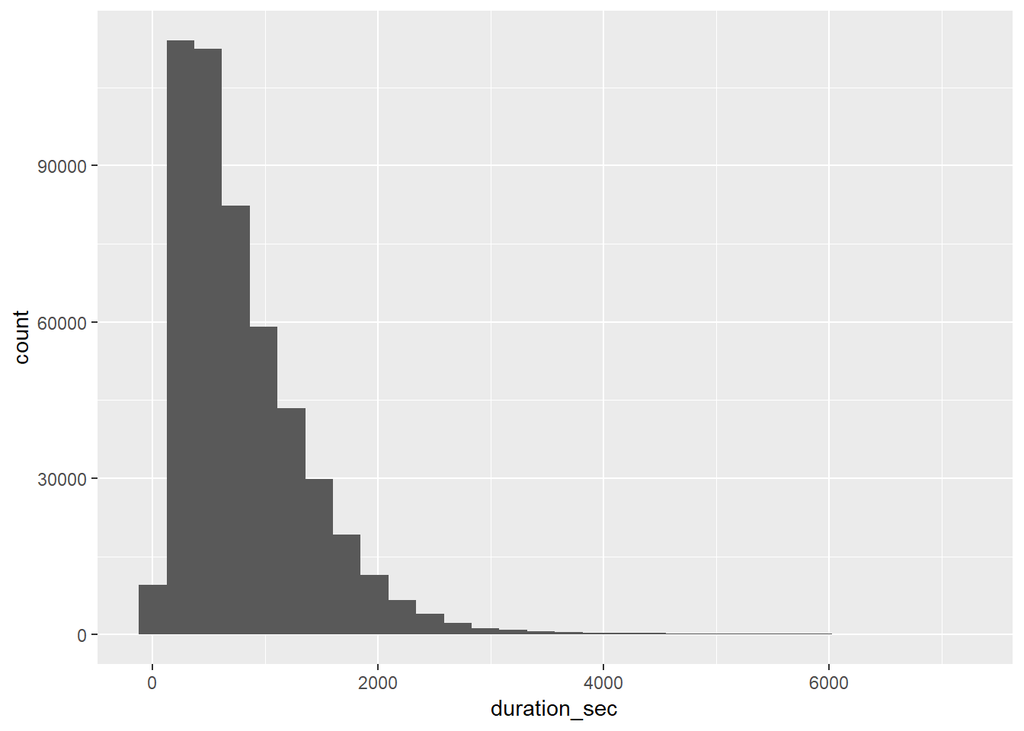

```r
bike %>% ggplot(aes(x = duration_sec)) +
  geom_histogram()
```

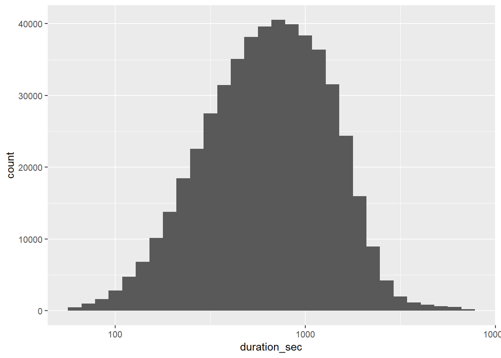

```r
bike %>% ggplot(aes(x = duration_sec)) +
  scale_x_log10() +
  geom_histogram()
```

### 5.1.2 Summaries of One Variable: Discrete

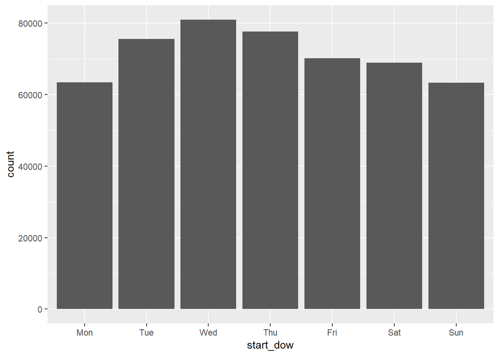

```r
bike %>% ggplot(aes(x = start_dow)) +
  geom_bar()
```

### 5.1.3 Summaries of One Variable: Temporal

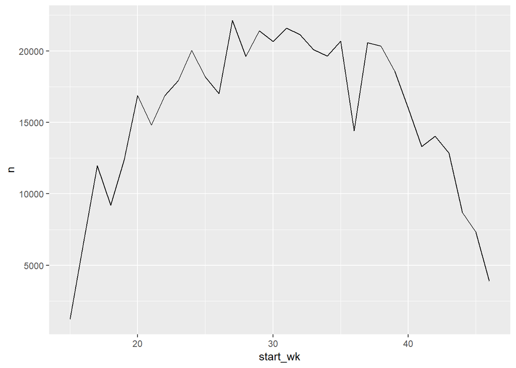

```r
bike %>%
  group_by(start_wk) %>%
  summarise(n = n()) %>%
  ggplot(aes(x = start_wk, y = n)) +
  geom_line()
```

## 5.2 Summarizing multiple variablea jointly

Ok, that was pretty easy. However, the insights gained so far are pretty little. To tease out interesting pattern in our data, it might not be enough to only look at one variable at a time. To display relationships between multiple variables, we mainly can:

- Use aestetics such as `col`, `fill`, `size`, `shape`
- Use `facet_wrap()`

Lets look at some examples:

First, we could take a look at the number of daily rides with workweek / weekend days colored differently.

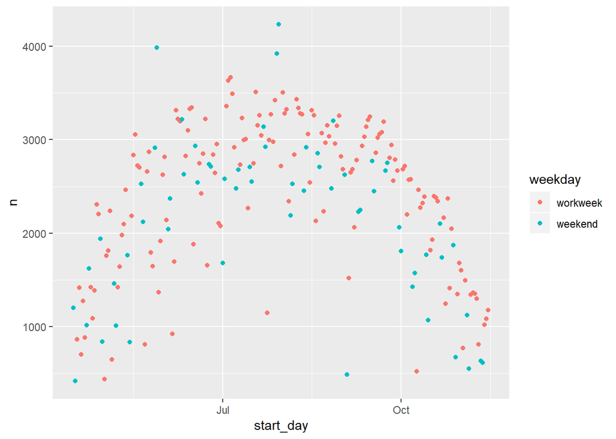

```r
# Compute daily counts
daily <- bike %>%
  group_by(start_day, weekday) %>%
  summarise(n = n())

# Plot the result
ggplot(daily, aes(start_day, n, color = weekday)) +
  geom_point()
```

Now let’s look at how rides are distributed according to the time of day. Let’s make a summary plot of weekly ride counts faceted by start hour of day and broken down by workweek/weekend. Here, we will use the `facet_grid`

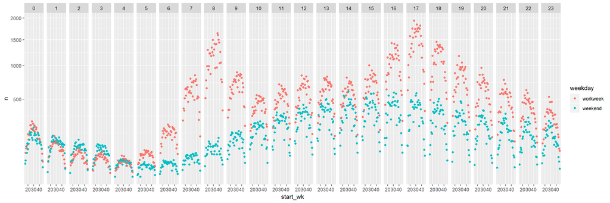

```r
# Compute week_hod
week_hod <- bike %>%
  group_by(start_wk, start_hod, weekday) %>%
  summarise(n = n())

# Plot the result
ggplot(week_hod, aes(start_wk, n, color = weekday)) +
  geom_point() +
  facet_grid(~ start_hod) +
  scale_y_sqrt()
```

Expanding on the previous plot, let’s add one more variable into our summary, adding a facet dimension for whether or not the rider is a member of BIXI.

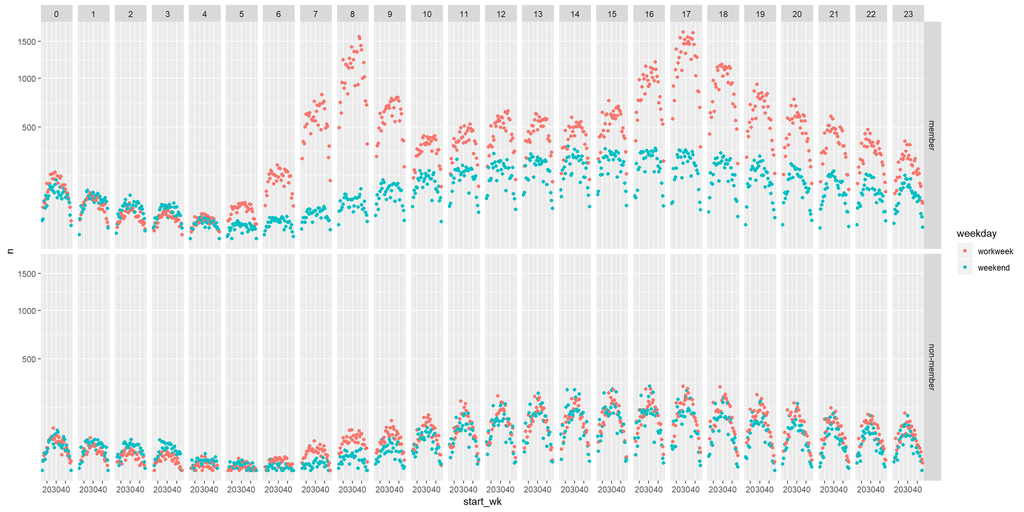

```r
# Compute wk_memb_hod
wk_memb_hod <- bike %>%
  group_by(start_wk, start_hod, weekday, membership) %>%
  summarise(n = n())

# Plot the result
ggplot(wk_memb_hod, aes(start_wk, n, color = weekday)) +
  geom_point() +
  facet_grid(membership ~ start_hod) +
  scale_y_sqrt()
```

Let’s now look at the number of rides vs. hour for each day. To start, we’ll create a summary dataset for the first full month in the dataset (May) and look at it.

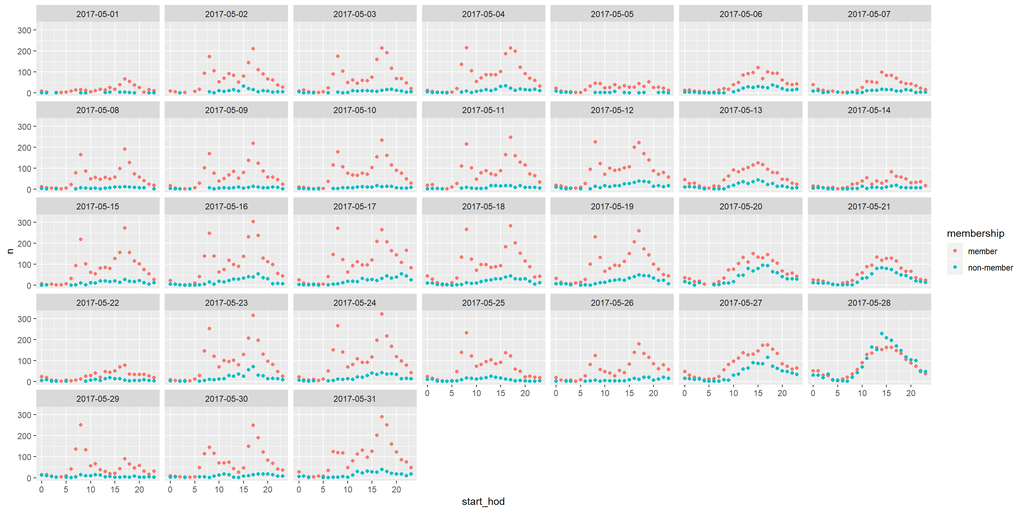

```r
# Compute daily_may
daily_may <- bike %>%
  filter(start_mon == 5) %>%
  group_by(start_day, start_hod, membership) %>%
  summarise(n = n())

# Plot the result
ggplot(daily_may, aes(start_hod, n, color = membership)) +
  geom_point() +
  facet_wrap(~ start_day, ncol = 7)
```

## 5.3 Your turn

Ok, its your turn again. We will take a look at the `gapminder` data, a dataset with a set of socio-economic macro indicators.

```r
library(gapminder)
data <- gapminder
data
```

| country | continent | year | lifeExp | pop | gdpPercap |
| --- | --- | --- | --- | --- | --- |
| Afghanistan | Asia | 1952 | 28.80100 | 8425333 | 779.4453 |
| Afghanistan | Asia | 1957 | 30.33200 | 9240934 | 820.8530 |
| Afghanistan | Asia | 1962 | 31.99700 | 10267083 | 853.1007 |
| Afghanistan | Asia | 1967 | 34.02000 | 11537966 | 836.1971 |
| Afghanistan | Asia | 1972 | 36.08800 | 13079460 | 739.9811 |
| Afghanistan | Asia | 1977 | 38.43800 | 14880372 | 786.1134 |
| Afghanistan | Asia | 1982 | 39.85400 | 12881816 | 978.0114 |
| Afghanistan | Asia | 1987 | 40.82200 | 13867957 | 852.3959 |
| Afghanistan | Asia | 1992 | 41.67400 | 16317921 | 649.3414 |
| Afghanistan | Asia | 1997 | 41.76300 | 22227415 | 635.3414 |

[output cut: 1694 more lines]

```r
data %>% glimpse()
```

```
## Observations: 1,704
## Variables: 6
## $ country   <fct> Afghanistan, Afghanistan, Afghanistan, Afghanistan, ...
## $ continent <fct> Asia, Asia, Asia, Asia, Asia, Asia, Asia, Asia, Asia...
## $ year      <int> 1952, 1957, 1962, 1967, 1972, 1977, 1982, 1987, 1992...
## $ lifeExp   <dbl> 28.801, 30.332, 31.997, 34.020, 36.088, 38.438, 39.8...
## $ pop       <int> 8425333, 9240934, 10267083, 11537966, 13079460, 1488...
## $ gdpPercap <dbl> 779.4453, 820.8530, 853.1007, 836.1971, 739.9811, 78...
```

```r
data %>% skim()
```

|  | variable | type | stat | level | value | formatted |
| --- | --- | --- | --- | --- | --- | --- |
| 1 | country | factor | missing | .all | 0.000000e+00 | 0 |
| 2 | country | factor | complete | .all | 1.704000e+03 | 1704 |
| 3 | country | factor | n | .all | 1.704000e+03 | 1704 |
| 4 | country | factor | n_unique | .all | 1.420000e+02 | 142 |
| 5 | country | factor | top_counts | Afghanistan | 1.200000e+01 | Afg: 12 |
| 6 | country | factor | top_counts | Albania | 1.200000e+01 | Alb: 12 |
| 7 | country | factor | top_counts | Algeria | 1.200000e+01 | Alg: 12 |
| 8 | country | factor | top_counts | Angola | 1.200000e+01 | Ang: 12 |
| 9 | country | factor | top_counts | Argentina | 1.200000e+01 | Arg: 12 |
| 10 | country | factor | top_counts | Australia | 1.200000e+01 | Aus: 12 |

[output cut: 193 more lines]

We see again a set of contiineous variables, categorical variables, and a time-dimension. Lets try to explore it a bit, try to use different types of visualizations and facets to dig into the following questions:

- How are countries, and continents, doing in terms of `lifeExp` and `gdpPercap`
- How did `lifeExp` and `gdpPercap` develop over time in general?
- Are there different trends across countries and continents to be seen?
- Does these trends seem to be related to `pop` or `gdpPercap`

Use different types of visualizations, facets, and aestetics (size, col, fill, shape), as well as summary functions.